# # 成人における自閉症スペクトラム障害（ASD）に関する研究

## 目次

- イントロダクション
- ETL（抽出、変換、ロード）
  - データの抽出と初期ロード
  - 変換
    - 探索的データ分析（EDA）およびデータ品質保証（DQA） (I)
- 教師なしモデル
  - 特徴エンジニアリング
    - K-Means モデル
    - DBSCAN と OPTICS モデル
    - 探索的データ分析（EDA）およびデータ品質保証（DQA） (II)
      - 変数間の関係の分析
- データセットの説明
  - ETLセクションの結論
- 教師ありモデル
  - ロジスティック回帰 - 二項分類
  - マルチクラス分類モデル
- モデルの選択
  - 変数選択の概要
- 結論
- 参考文献

## イントロダクション

***自閉症スペクトラム障害 (ASD)*** は、コミュニケーション、社会的相互作用、行動に影響を与える神経発達障害です。成人におけるASDの早期かつ正確な検出は、彼らの生活の質を向上させるために必要なサポートと介入を提供するために非常に重要です。

このプロジェクトは、寄与する要因を調査し、人口統計データとスクリーニング質問票への回答に基づいて、成人におけるASDリスクを予測する機械学習モデルを開発することを目的としています。我々は、UCI Machine Learningリポジトリからの「Autism Screening Adult」データセット [UCI Machine Learning](https://archive.ics.uci.edu/dataset/426/autism+screening+adult) を使用します。このデータセットには704人の成人に関する情報が含まれており、彼らの自閉症スペクトラム指数 (AQ) テストのスコアとASDの臨床診断が記録されています。

我々のアプローチは、データの準備と探索的データ分析 (EDA) を皮切りに、複数のモデル戦略を採用します。元のデータセットを特定の機械学習モデルに最適化されたデータセットに変換し、それぞれに応じた最適化を行います。

1. バイナリ分類モデル:  
   このモデルでは、個人がASDであるかどうかを予測することに焦点を当て、問題を2クラス分類に簡略化します。
2. マルチクラス分類モデル:  
   このモデルはバイナリ分類を超え、異なるASDリスクレベルを予測し、より個別化された評価を提供しようと試みます。

各モデルについて、特定のアルゴリズムを選択して訓練し、そのパフォーマンスを評価し、結果を比較します。ロジスティック回帰、決定木、サポートベクターマシンなどの技術を探り、それぞれのアプローチに最も正確で適切なモデルを特定することを目指します。

予測モデルの開発に加えて、このプロジェクトは、**成人におけるASDリスクに影響を与える要因**の理解に貢献することを目指しています。さまざまな特徴の重要性とASDの診断との関連を分析し、将来の研究や介入戦略に貴重な洞察を提供できる可能性があります。

***キーワード:***  
自閉症スペクトラム障害、機械学習、バイナリ分類、マルチクラス分類、AQテスト、診断、予測。

## ETL (抽出、変換、ロード)

### データの抽出と初期ロード

このプロジェクトのデータソースは、UCI Machine Learningリポジトリから公開されている「Autism Screening Adult」データセットです。データはARFF (Attribute-Relation File Format) 形式で提供されており、これはデータとメタデータを一緒に保存できるデータマイニングで一般的な形式です。

Pythonでの操作と分析を容易にするために、データはARFFファイルからPandas DataFrameにロードされました。Pandasはデータサイエンスで広く使用されている表形式のデータ構造です。この初期の抽出とロードのステップにより、データにアクセスでき、変換と探索のプロセスを開始することができました。

```python
# importamos las librerias
import tensorflow as tf
import pandas as pd
import keras as kr
import scipy as scp
import numpy as np
```

Loading the dataset, originally in `.arff` format:

```python
# Importamos el dataset en formato arff
from scipy.io import arff
dataSet, meta = arff.loadarff("autism_adult.arff")
# Observamos que tenemos un array de numpy
type(dataSet)
```

```
numpy.ndarray
```

### データの前処理

データセットには欠損値や一貫性のない値が含まれている可能性があるため、分析やモデリングを進める前にクリーニングと前処理を行うことが不可欠です。Pythonの強力なデータ分析ライブラリであるPandasは、このタスクに効率的なツールを提供しています。

**データの読み込み**

```python
# Convertimos en un dataframe de pandas:
df = pd.DataFrame(dataSet)
# Mostramos los primeros registros
df.head()
```

|  | A1_Score | A2_Score | A3_Score | A4_Score | A5_Score | A6_Score | A7_Score | A8_Score | A9_Score | A10_Score | ... | gender | ethnicity | jundice | austim | contry_of_res | used_app_before | result | age_desc | relation | Class/ASD |
| --- | --- | --- | --- | --- | --- | --- | --- | --- | --- | --- | --- | --- | --- | --- | --- | --- | --- | --- | --- | --- | --- |
| 0 | b'1' | b'1' | b'1' | b'1' | b'0' | b'0' | b'1' | b'1' | b'0' | b'0' | ... | b'f' | b'White-European' | b'no' | b'no' | b'United States' | b'no' | 6.0 | b'18 and more' | b'Self' | b'NO' |
| 1 | b'1' | b'1' | b'0' | b'1' | b'0' | b'0' | b'0' | b'1' | b'0' | b'1' | ... | b'm' | b'Latino' | b'no' | b'yes' | b'Brazil' | b'no' | 5.0 | b'18 and more' | b'Self' | b'NO' |
| 2 | b'1' | b'1' | b'0' | b'1' | b'1' | b'0' | b'1' | b'1' | b'1' | b'1' | ... | b'm' | b'Latino' | b'yes' | b'yes' | b'Spain' | b'no' | 8.0 | b'18 and more' | b'Parent' | b'YES' |
| 3 | b'1' | b'1' | b'0' | b'1' | b'0' | b'0' | b'1' | b'1' | b'0' | b'1' | ... | b'f' | b'White-European' | b'no' | b'yes' | b'United States' | b'no' | 6.0 | b'18 and more' | b'Self' | b'NO' |
| 4 | b'1' | b'0' | b'0' | b'0' | b'0' | b'0' | b'0' | b'1' | b'0' | b'0' | ... | b'f' | b'?' | b'no' | b'no' | b'Egypt' | b'no' | 2.0 | b'18 and more' | b'?' | b'NO' |

5 rows × 21 columns

### 変換

#### データ変換

この重要な段階では、元のARFFファイルから抽出されたデータをクリーニング、修正、準備するために一連の操作と技術が適用されました。この段階の主な目的は、データの品質、一貫性、および後続の分析と機械学習モデリングへの適合性を確保することでした。

欠損値や一貫性のないカテゴリーなどの一般的なデータ品質の問題に対処しました。さらに、カテゴリー変数を機械学習アルゴリズムに適した数値形式に変換するためのエンコーディング戦略が実装されました。特徴量エンジニアリングもこの段階で重要な役割を果たし、新しい変数の作成や既存の変数の変換を可能にし、予測力を向上させました。

最後に、目標変数に存在するクラスの不均衡に対処するためにリサンプリング技術が適用され、データセット内のさまざまなカテゴリーのより公平な表現が確保されました。

```python
# Convertimos las columnas a string
# para poder solucionar el problema
# tipico del formato 'weka
for column in df.columns:
    if df[column].dtype == 'object':
        df[column] = df[column].astype(str)
# Comprobamos el formato de los registros
df.head()
```

|  | A1_Score | A2_Score | A3_Score | A4_Score | A5_Score | A6_Score | A7_Score | A8_Score | A9_Score | A10_Score | ... | gender | ethnicity | jundice | austim | contry_of_res | used_app_before | result | age_desc | relation | Class/ASD |
| --- | --- | --- | --- | --- | --- | --- | --- | --- | --- | --- | --- | --- | --- | --- | --- | --- | --- | --- | --- | --- | --- |
| 0 | 1 | 1 | 1 | 1 | 0 | 0 | 1 | 1 | 0 | 0 | ... | f | White-European | no | no | United States | no | 6.0 | 18 and more | Self | NO |
| 1 | 1 | 1 | 0 | 1 | 0 | 0 | 0 | 1 | 0 | 1 | ... | m | Latino | no | yes | Brazil | no | 5.0 | 18 and more | Self | NO |
| 2 | 1 | 1 | 0 | 1 | 1 | 0 | 1 | 1 | 1 | 1 | ... | m | Latino | yes | yes | Spain | no | 8.0 | 18 and more | Parent | YES |
| 3 | 1 | 1 | 0 | 1 | 0 | 0 | 1 | 1 | 0 | 1 | ... | f | White-European | no | yes | United States | no | 6.0 | 18 and more | Self | NO |
| 4 | 1 | 0 | 0 | 0 | 0 | 0 | 0 | 1 | 0 | 0 | ... | f | ? | no | no | Egypt | no | 2.0 | 18 and more | ? | NO |

5 rows × 21 columns

```python
# Comprobamos si hay valores null en el DataFrame
# Porcentaje de valores nulos en el dataset
df.isnull().sum()/len(df)*100
```

```
A1_Score           0.000000
A2_Score           0.000000
A3_Score           0.000000
A4_Score           0.000000
A5_Score           0.000000
A6_Score           0.000000
A7_Score           0.000000
A8_Score           0.000000
A9_Score           0.000000
A10_Score          0.000000
age                0.284091
gender             0.000000
ethnicity          0.000000
jundice            0.000000
austim             0.000000
contry_of_res      0.000000
used_app_before    0.000000
result             0.000000
age_desc           0.000000
relation           0.000000
Class/ASD          0.000000
dtype: float64
```

```python
# Visualizamos con otro metodo:
df.info()
```

```
<class 'pandas.core.frame.DataFrame'>
RangeIndex: 704 entries, 0 to 703
Data columns (total 21 columns):
 #   Column           Non-Null Count  Dtype
---  ------           --------------  -----
 0   A1_Score         704 non-null    object
 1   A2_Score         704 non-null    object
 2   A3_Score         704 non-null    object
 3   A4_Score         704 non-null    object
 4   A5_Score         704 non-null    object
 5   A6_Score         704 non-null    object
 6   A7_Score         704 non-null    object
 7   A8_Score         704 non-null    object
 8   A9_Score         704 non-null    object
 9   A10_Score        704 non-null    object
 10  age              702 non-null    float64
 11  gender           704 non-null    object
 12  ethnicity        704 non-null    object
 13  jundice          704 non-null    object
 14  austim           704 non-null    object
 15  contry_of_res    704 non-null    object
 16  used_app_before  704 non-null    object
 17  result           704 non-null    float64
 18  age_desc         704 non-null    object
 19  relation         704 non-null    object
 20  Class/ASD        704 non-null    object
dtypes: float64(2), object(19)
memory usage: 115.6+ KB
```

We eliminated missing values in the variable age ('age'). Since there was a minimal percentage (0.28%) of missing values (2 records), we proceeded to eliminate the corresponding rows:

```python
# eliminamos los registros con valores null:
df = df.dropna()
df.info()
```

```
<class 'pandas.core.frame.DataFrame'>
Index: 702 entries, 0 to 703
Data columns (total 21 columns):
 #   Column           Non-Null Count  Dtype
---  ------           --------------  -----
 0   A1_Score         702 non-null    object
 1   A2_Score         702 non-null    object
 2   A3_Score         702 non-null    object
 3   A4_Score         702 non-null    object
 4   A5_Score         702 non-null    object
 5   A6_Score         702 non-null    object
 6   A7_Score         702 non-null    object
 7   A8_Score         702 non-null    object
 8   A9_Score         702 non-null    object
 9   A10_Score        702 non-null    object
 10  age              702 non-null    float64
 11  gender           702 non-null    object
 12  ethnicity        702 non-null    object
 13  jundice          702 non-null    object
 14  austim           702 non-null    object
 15  contry_of_res    702 non-null    object
 16  used_app_before  702 non-null    object
 17  result           702 non-null    float64
 18  age_desc         702 non-null    object
 19  relation         702 non-null    object
 20  Class/ASD        702 non-null    object
dtypes: float64(2), object(19)
memory usage: 120.7+ KB
```

We notice that two records have been deleted. We proceed to clean the field or attribute names by converting them to lowercase and normalizing them:

```python
# Convertimos a minusculas los nombres de las columnas:
df.columns = df.columns.str.lower()
print(df.columns)
```

```
Index(['a1_score', 'a2_score', 'a3_score', 'a4_score', 'a5_score', 'a6_score',
       'a7_score', 'a8_score', 'a9_score', 'a10_score', 'age', 'gender',
       'ethnicity', 'jundice', 'austim', 'contry_of_res', 'used_app_before',
       'result', 'age_desc', 'relation', 'class/asd'],
      dtype='object')
```

```python
# Normalizamos los nombres de campo
df.columns = df.columns.str.replace('[^a-zA-Z0-9]', '_', regex=True)
print(df.columns)
```

```
Index(['a1_score', 'a2_score', 'a3_score', 'a4_score', 'a5_score', 'a6_score',
       'a7_score', 'a8_score', 'a9_score', 'a10_score', 'age', 'gender',
       'ethnicity', 'jundice', 'austim', 'contry_of_res', 'used_app_before',
       'result', 'age_desc', 'relation', 'class_asd'],
      dtype='object')
```

**AQ-10質問票とデータセットにおけるその表現**  
自閉症スペクトラム指数（AQ-10）は、成人の自閉症特性を評価するために設計された10項目の自己報告質問票です。各質問には、「強くそう思う」から「全くそう思わない」までの回答選択肢があり、各回答は数値としてエンコードされています。これらの個々のスコアの合計が総スコアとなり、個人が自閉症特性を示す可能性の指標として解釈されます。

[使用されたデータセット](https://archive.ics.uci.edu/ml/datasets/Autism+Screening+Adult)では、「A1_Score」、「A2_Score」などの属性が、AQ-10の10の質問それぞれに対して得られたスコアを表しています。これらのスコアは本質的に数値であるため、'object'または'float'データ型として読み込まれた列は、後続の分析で適切に利用できるよう整数（int）型に変換されました。

```python
# importamos la libreria para expresiones regulares
import re

# Convertimos a int
for column in df.columns:
    if re.match(r'^a\d+', column) and df[column].dtype == 'object':
        try:
            df[column] = pd.to_numeric(df[column])
        except ValueError:
            print(f"Advertencia: La columna'{column}'contiene valores"
                  "no numéricos y no se pudo convertir")
# Revisamos que los campos han cambiado de tipo adecuadamente
df.info()
```

```
<class 'pandas.core.frame.DataFrame'>
Index: 702 entries, 0 to 703
Data columns (total 21 columns):
 #   Column           Non-Null Count  Dtype
---  ------           --------------  -----
 0   a1_score         702 non-null    int64
 1   a2_score         702 non-null    int64
 2   a3_score         702 non-null    int64
 3   a4_score         702 non-null    int64
 4   a5_score         702 non-null    int64
 5   a6_score         702 non-null    int64
 6   a7_score         702 non-null    int64
 7   a8_score         702 non-null    int64
 8   a9_score         702 non-null    int64
 9   a10_score        702 non-null    int64
 10  age              702 non-null    float64
 11  gender           702 non-null    object
 12  ethnicity        702 non-null    object
 13  jundice          702 non-null    object
 14  austim           702 non-null    object
 15  contry_of_res    702 non-null    object
 16  used_app_before  702 non-null    object
 17  result           702 non-null    float64
 18  age_desc         702 non-null    object
 19  relation         702 non-null    object
 20  class_asd        702 non-null    object
dtypes: float64(2), int64(10), object(9)
memory usage: 120.7+ KB
```

We examined the age column aiming to identify any potential outliers or extreme values.

```python
# Marcamos valores mayores a 115 como NaN (Not a Number)
df.loc[df['age'] > 115, 'age'] = float('nan')

# Eliminamos filas con valores NaN en la columna 'age'
df.dropna(subset=['age'], inplace=True)
df.info()
```

```
<class 'pandas.core.frame.DataFrame'>
Index: 701 entries, 0 to 703
Data columns (total 21 columns):
 #   Column           Non-Null Count  Dtype
---  ------           --------------  -----
 0   a1_score         701 non-null    int64
 1   a2_score         701 non-null    int64
 2   a3_score         701 non-null    int64
 3   a4_score         701 non-null    int64
 4   a5_score         701 non-null    int64
 5   a6_score         701 non-null    int64
 6   a7_score         701 non-null    int64
 7   a8_score         701 non-null    int64
 8   a9_score         701 non-null    int64
 9   a10_score        701 non-null    int64
 10  age              701 non-null    float64
 11  gender           701 non-null    object
 12  ethnicity        701 non-null    object
 13  jundice          701 non-null    object
 14  austim           701 non-null    object
 15  contry_of_res    701 non-null    object
 16  used_app_before  701 non-null    object
 17  result           701 non-null    float64
 18  age_desc         701 non-null    object
 19  relation         701 non-null    object
 20  class_asd        701 non-null    object
dtypes: float64(2), int64(10), object(9)
memory usage: 120.5+ KB
```

An identified outlier in the age attribute was removed. Subsequently, this attribute was converted to an integer data type.

```python
# Cambiamos el campo edad a 'int':
df['age'] = df['age'].astype(int)
df.info()
```

```
<class 'pandas.core.frame.DataFrame'>
Index: 701 entries, 0 to 703
Data columns (total 21 columns):
 #   Column           Non-Null Count  Dtype
---  ------           --------------  -----
 0   a1_score         701 non-null    int64
 1   a2_score         701 non-null    int64
 2   a3_score         701 non-null    int64
 3   a4_score         701 non-null    int64
 4   a5_score         701 non-null    int64
 5   a6_score         701 non-null    int64
 6   a7_score         701 non-null    int64
 7   a8_score         701 non-null    int64
 8   a9_score         701 non-null    int64
 9   a10_score        701 non-null    int64
 10  age              701 non-null    int64
 11  gender           701 non-null    object
 12  ethnicity        701 non-null    object
 13  jundice          701 non-null    object
 14  austim           701 non-null    object
 15  contry_of_res    701 non-null    object
 16  used_app_before  701 non-null    object
 17  result           701 non-null    float64
 18  age_desc         701 non-null    object
 19  relation         701 non-null    object
 20  class_asd        701 non-null    object
dtypes: float64(1), int64(11), object(9)
memory usage: 120.5+ KB
```

We reviewed the attributes again:

```python
# Obtenemos las columnas
print(df.columns)
```

```
Index(['a1_score', 'a2_score', 'a3_score', 'a4_score', 'a5_score', 'a6_score',
       'a7_score', 'a8_score', 'a9_score', 'a10_score', 'age', 'gender',
       'ethnicity', 'jundice', 'austim', 'contry_of_res', 'used_app_before',
       'result', 'age_desc', 'relation', 'class_asd'],
      dtype='object')
```

Subsequently, we will analyzed the gender field, which comprises two categories: "male" and "female."

```python
# Importamos la libreria sklern
from sklearn.preprocessing import LabelEncoder

# Creamos una variable
le = LabelEncoder()

# Etiquetamos la variable categorica 'gender':
df['gender'] = le.fit_transform(df['gender'])

# Imprimimos las clases:
print(le.classes_)
```

```
['f' 'm']
```

The gender column will be encoded as follows: 0 for "Female" and 1 for "Male".

Next, we will analyze the categorical variable ethnicity. We will begin by examining the distribution of its values within the DataFrame.

```python
# Dilucidamos el numero de etnias en el df
df['ethnicity'].value_counts()
```

```
ethnicity
White-European     233
Asian              123
?                   93
Middle Eastern      92
Black               43
South Asian         36
Others              30
Latino              20
Hispanic            13
Pasifika            11
Turkish              6
others               1
Name: count, dtype: int64
```

The presence of the character '?' was observed in the ethnicity column, indicating missing or unknown data. It was decided to group these values into the 'Others' category to simplify the analysis. Additionally, an inconsistency was identified in the 'others' category, which was standardized to 'Others' to maintain data consistency.

Subsequently, further transformations were performed on the categories within the ethnicity variable.

```python
# Reemplazamos valores específicos en la columna 'ethnicity'
df['ethnicity'] = df['ethnicity'].replace(['?', 'others'], 'Others')
# Y observamos si hemos agrupado todo bajo la categoria 'Others'
df['ethnicity'].value_counts()
```

```
ethnicity
White-European     233
Others             124
Asian              123
Middle Eastern      92
Black               43
South Asian         36
Latino              20
Hispanic            13
Pasifika            11
Turkish              6
Name: count, dtype: int64
```

Some categories seemed redundant, such as 'Hispanic' and 'Latino', so we proceeded to group them:

```python
# Reemplazamos otros valores en la columna 'ethnicity'
df['ethnicity'] = df['ethnicity'].replace(['Hispanic', 'Latino'], 'Latin')
df['ethnicity'] = df['ethnicity'].replace('White-European', 'White')
# Y observamos si hemos agrupado todo bajo la categorias antes especificadas
df['ethnicity'].value_counts()
```

```
ethnicity
White              233
Others             124
Asian              123
Middle Eastern      92
Black               43
South Asian         36
Latin               33
Pasifika            11
Turkish              6
Name: count, dtype: int64
```

We included the categories with fewer records 'Pasifika' and 'Turkish' in 'Others' to avoid problems with the model:

```python
# Agrupamos registros de etnias minoritarias
df['ethnicity'] = df['ethnicity'].replace(['Pasifika', 'Turkish'], 'Others')
# Observamos si hemos agrupado
df['ethnicity'].value_counts()
```

```
ethnicity
White              233
Others             141
Asian              123
Middle Eastern      92
Black               43
South Asian         36
Latin               33
Name: count, dtype: int64
```

```python
# Limpiamos la columna 'ethnicity' de espacios en blanco
df['ethnicity'] = df['ethnicity'].astype(str).str.strip()
```

We mapped the categories within the 'ethnicity' attribute by creating a dictionary:

```python
# mapeando los valores
eth_map = {
    "White": 1,
    "Asian": 2,
    "Middle Eastern": 3,
    "Black": 4,
    "South Asian": 5,
    "Latin": 6,
    "Others": 7
}
# comprobamos los pares clave - valor
print(eth_map)
```

```
{'White': 1, 'Asian': 2, 'Middle Eastern': 3, 'Black': 4, 'South Asian': 5, 'Latin': 6, 'Others': 7}
```

```python
# Asignamos el resultado del mapeo a la columna 'eth_cat'
df['eth_cat'] = df['ethnicity'].map(eth_map)
df[['ethnicity', 'eth_cat']].head(10)
```

|  | ethnicity | eth_cat |
| --- | --- | --- |
| 0 | White | 1 |
| 1 | Latin | 6 |
| 2 | Latin | 6 |
| 3 | White | 1 |
| 4 | Others | 7 |
| 5 | Others | 7 |
| 6 | Black | 4 |
| 7 | White | 1 |
| 8 | White | 1 |
| 9 | Asian | 2 |

```python
# Aseguramos que la columna 'eth_cat' sea de tipo int64
df['eth_cat'] = df['eth_cat'].astype('int64')
# Observamos los resultados:
df.info()
```

```
<class 'pandas.core.frame.DataFrame'>
Index: 701 entries, 0 to 703
Data columns (total 22 columns):
 #   Column           Non-Null Count  Dtype
---  ------           --------------  -----
 0   a1_score         701 non-null    int64
 1   a2_score         701 non-null    int64
 2   a3_score         701 non-null    int64
 3   a4_score         701 non-null    int64
 4   a5_score         701 non-null    int64
 5   a6_score         701 non-null    int64
 6   a7_score         701 non-null    int64
 7   a8_score         701 non-null    int64
 8   a9_score         701 non-null    int64
 9   a10_score        701 non-null    int64
 10  age              701 non-null    int64
 11  gender           701 non-null    int64
 12  ethnicity        701 non-null    object
 13  jundice          701 non-null    object
 14  austim           701 non-null    object
 15  contry_of_res    701 non-null    object
 16  used_app_before  701 non-null    object
 17  result           701 non-null    float64
 18  age_desc         701 non-null    object
 19  relation         701 non-null    object
 20  class_asd        701 non-null    object
 21  eth_cat          701 non-null    int64
dtypes: float64(1), int64(13), object(8)
memory usage: 126.0+ KB
```

When creating ML models, the categorical variable 'ethnicity' seemed to have no usefulness, so we proceeded to eliminate it:

```python
# Eliminamos la columna 'ethnicity'
df.drop(columns=['ethnicity'], inplace=True)
df.info()
```

```
<class 'pandas.core.frame.DataFrame'>
Index: 701 entries, 0 to 703
Data columns (total 21 columns):
 #   Column           Non-Null Count  Dtype
---  ------           --------------  -----
 0   a1_score         701 non-null    int64
 1   a2_score         701 non-null    int64
 2   a3_score         701 non-null    int64
 3   a4_score         701 non-null    int64
 4   a5_score         701 non-null    int64
 5   a6_score         701 non-null    int64
 6   a7_score         701 non-null    int64
 7   a8_score         701 non-null    int64
 8   a9_score         701 non-null    int64
 9   a10_score        701 non-null    int64
 10  age              701 non-null    int64
 11  gender           701 non-null    int64
 12  jundice          701 non-null    object
 13  austim           701 non-null    object
 14  contry_of_res    701 non-null    object
 15  used_app_before  701 non-null    object
 16  result           701 non-null    float64
 17  age_desc         701 non-null    object
 18  relation         701 non-null    object
 19  class_asd        701 non-null    object
 20  eth_cat          701 non-null    int64
dtypes: float64(1), int64(13), object(7)
memory usage: 120.5+ KB
```

AQ-10 テスト結果の二値化 AQ-10 テスト結果を二値化し、潜在的な自閉症ケースの特定を容易にする必要性が認められました。テスト基準によると、6点以上のスコアは専門的な評価の必要性を示し、6点未満のスコアは ASD の可能性が低いことを示唆します。

したがって、 aq_binary という新しい二値変数が作成されました。 6点以上のスコアは True（1）としてエンコードされ、6点未満のスコアは False（0）としてエンコードされました。この変換により、この変数を以降の分析で自閉症リスクの簡略化された指標として使用できます。

```python
# Creamos una variable binaria para AQ
df['aq_binary'] = (df['result'] >= 6).astype('int64')
df.info()
```

```
<class 'pandas.core.frame.DataFrame'>
Index: 701 entries, 0 to 703
Data columns (total 22 columns):
 #   Column           Non-Null Count  Dtype
---  ------           --------------  -----
 0   a1_score         701 non-null    int64
 1   a2_score         701 non-null    int64
 2   a3_score         701 non-null    int64
 3   a4_score         701 non-null    int64
 4   a5_score         701 non-null    int64
 5   a6_score         701 non-null    int64
 6   a7_score         701 non-null    int64
 7   a8_score         701 non-null    int64
 8   a9_score         701 non-null    int64
 9   a10_score        701 non-null    int64
 10  age              701 non-null    int64
 11  gender           701 non-null    int64
 12  jundice          701 non-null    object
 13  austim           701 non-null    object
 14  contry_of_res    701 non-null    object
 15  used_app_before  701 non-null    object
 16  result           701 non-null    float64
 17  age_desc         701 non-null    object
 18  relation         701 non-null    object
 19  class_asd        701 non-null    object
 20  eth_cat          701 non-null    int64
 21  aq_binary        701 non-null    int64
dtypes: float64(1), int64(14), object(7)
memory usage: 126.0+ KB
```

黄疸と自閉症診断の関連性分析 出生時に黄疸があったかどうかを示す属性 'jundice' を調査しました。サンプル内で、出生時の黄疸の存在と自閉症診断の間に関連性があるかどうかを判断するための分析を実施しました。

```python
# Creamos una variable para las etiquetas ictericia
le = LabelEncoder()
# Etiquetamos la variable categorica 'jundice':
df['jundice'] = le.fit_transform(df['jundice'])
# Imprimimos las clases
print(le.classes_)
```

```
['no' 'yes']
```

We observe that, indeed, **'no'** has been encoded as 0 and **'yes'** as 1, respectively. We verified if the changes have indeed occurred:

```python
# Comprobamos el atributo 'jundice':
df['jundice'].head(8)
```

```
0    0
1    0
2    1
3    0
4    0
5    1
6    0
7    0
Name: jundice, dtype: int64
```

The target variable austim, representing the autism diagnosis, was encoded.

```python
# re-creamos la variable
le = LabelEncoder()
# Etiquetamos la variable categorica 'austim':
df['austim'] = le.fit_transform(df['austim'])
# Imprimimos las clases
print(le.classes_)
```

```
['no' 'yes']
```

The encoding of the austim variable was established, assigning the value 0 to the "no" category and the value 1 to the "yes" category.

Subsequently, the distribution of the target variable austim was analyzed to assess the balance between classes (presence or absence of autism diagnosis) and to verify that the attribute type was suitable for use in machine learning models.

```python
# Contamos los valores:
df['austim'].value_counts()
```

```
austim
0    610
1     91
Name: count, dtype: int64
```

データ変換とクラス不均衡への対応 データ変換は有望な結果をもたらしましたが、サンプル内でクラス不均衡が確認されたため、モデル訓練中にリサンプリング技術を実装する必要性が生じました。SMOTE（Synthetic Minority Over-sampling Technique）または ADASYN（Adaptive Synthetic Sampling）のいずれかを利用することが決定されました。これらの手法は、データセットのバランスを取るために少数クラスの合成サンプルを生成することができます。

居住国属性の分析 次に調査された属性は、参加者の居住国を示す country_of_res でした。当初、分析に民族性が含まれていることから冗長である可能性が考慮されましたが、探索的データ分析フェーズにおいて、民族性および自閉症診断との関係を探るために、この属性を一時的に保持することが決定されました。

これらの変数間に有意な関連性があるかどうかを調べるために、分割表、カイ二乗検定、および視覚化などの手法が採用されました。

以下に、このフィールドの内容の詳細な分析を示します。

```python
# Comprobamos el atributo 'contry_of_res':
df['contry_of_res'].value_counts()
```

```
contry_of_res
United States           113
United Arab Emirates     82
India                    81
New Zealand              80
United Kingdom           77
                       ...
China                     1
Chile                     1
Lebanon                   1
Burundi                   1
Cyprus                    1
Name: count, Length: 67, dtype: int64
```

居住国属性のエンコーディング データセットには67の異なる国が存在し、一部の国はサンプル数が非常に少ないため、One-Hot Encoding や Mean Encoding などのエンコーディング技術が検討されました。しかし、さまざまな機械学習モデルの適用に適したコンパクトなデータセットを取得する必要性を考慮し、Label Encoding を使用して各国をエンコードすることが決定されました。

```python
le = LabelEncoder()
df['res_code'] = le.fit_transform(df['contry_of_res'])

# Obtenemos el mapeo de etiquetas a códigos
code_mapping = dict(zip(le.classes_, le.transform(le.classes_)))
print(code_mapping)
```

```
{'Afghanistan': 0, 'AmericanSamoa': 1, 'Angola': 2, 'Argentina': 3, 'Armenia': 4, 'Aruba': 5, 'Australia': 6, 'Austria': 7, 'Azerbaijan': 8, 'Bahamas': 9, 'Bangladesh': 10, 'Belgium': 11, 'Bolivia': 12, 'Brazil': 13, 'Burundi': 14, 'Canada': 15, 'Chile': 16, 'China': 17, 'Costa Rica': 18, 'Cyprus': …
```

We proceeded to export the data for later queries to a `JSON` format:

```python
# import la libreria json
import json
# Convertimos los valores a enteros de Python
for key, value in code_mapping.items():
    code_mapping[key] = int(value)

with open('country_code_mapping.json', 'w') as f:
    json.dump(code_mapping, f)
```

```python
# Revisamos la asignación de códigos
df[['contry_of_res', 'res_code']].head(10)
```

|  | contry_of_res | res_code |
| --- | --- | --- |
| 0 | United States | 64 |
| 1 | Brazil | 13 |
| 2 | Spain | 56 |
| 3 | United States | 64 |
| 4 | Egypt | 22 |
| 5 | United States | 64 |
| 6 | United States | 64 |
| 7 | New Zealand | 43 |
| 8 | United States | 64 |
| 9 | Bahamas | 9 |

Once the countries are encoded, we can remove the 'country_of_res' attribute

```python
# eliminamos 'country_of_res'
df.drop(columns=['contry_of_res'], inplace=True)
# Observamos los resultados:
df.info()
```

```
<class 'pandas.core.frame.DataFrame'>
Index: 701 entries, 0 to 703
Data columns (total 22 columns):
 #   Column           Non-Null Count  Dtype
---  ------           --------------  -----
 0   a1_score         701 non-null    int64
 1   a2_score         701 non-null    int64
 2   a3_score         701 non-null    int64
 3   a4_score         701 non-null    int64
 4   a5_score         701 non-null    int64
 5   a6_score         701 non-null    int64
 6   a7_score         701 non-null    int64
 7   a8_score         701 non-null    int64
 8   a9_score         701 non-null    int64
 9   a10_score        701 non-null    int64
 10  age              701 non-null    int64
 11  gender           701 non-null    int64
 12  jundice          701 non-null    int64
 13  austim           701 non-null    int64
 14  used_app_before  701 non-null    object
 15  result           701 non-null    float64
 16  age_desc         701 non-null    object
 17  relation         701 non-null    object
 18  class_asd        701 non-null    object
 19  eth_cat          701 non-null    int64
 20  aq_binary        701 non-null    int64
 21  res_code         701 non-null    int64
dtypes: float64(1), int64(17), object(4)
memory usage: 126.0+ KB
```

次に分析対象となった属性は、used_app_beforeで、これは参加者が以前に自閉症関連のアプリケーションを使用したことがあるかどうかを示していました。この属性の関連性は、以下の考慮事項を踏まえて、研究の文脈内で評価されました：

- トピックに対する親密度： アプリケーションの事前使用は、自閉症に関するより深い知識や、関連情報やサポートを積極的に探していることを示唆する可能性があります。
- 潜在的な選択バイアス： アプリケーションの使用は、それを使用した参加者と使用しなかった参加者の間の差異を示す可能性があり、結果にバイアスを導入する可能性があります。
- アプリケーションの潜在的効果： 使用されたアプリケーションが介入ツールであった場合、その事前使用は参加者の行動や症状の変化と関連している可能性があります。

```python
# Contamos los valores:
df['used_app_before'].value_counts()
```

```
used_app_before
no     689
yes     12
Name: count, dtype: int64
```

'はい' のケース数が少なく、偏りの可能性があるため、分析のこの初期段階で 'はい' のケースと変数を削除することにしました。これにより、より均質な被験者グループに基づいて、より堅牢で一般化可能なモデルを構築できます。

```python
# Filtramos los registros que no han usado la app:
df = df[df['used_app_before'] == 'no'].copy()

# Eliminamos la columna 'used_app_before'
df.drop(columns=['used_app_before'], inplace=True)

# Observamos los resultados:
df.info()
```

```
<class 'pandas.core.frame.DataFrame'>
Index: 689 entries, 0 to 703
Data columns (total 21 columns):
 #   Column     Non-Null Count  Dtype
---  ------     --------------  -----
 0   a1_score   689 non-null    int64
 1   a2_score   689 non-null    int64
 2   a3_score   689 non-null    int64
 3   a4_score   689 non-null    int64
 4   a5_score   689 non-null    int64
 5   a6_score   689 non-null    int64
 6   a7_score   689 non-null    int64
 7   a8_score   689 non-null    int64
 8   a9_score   689 non-null    int64
 9   a10_score  689 non-null    int64
 10  age        689 non-null    int64
 11  gender     689 non-null    int64
 12  jundice    689 non-null    int64
 13  austim     689 non-null    int64
 14  result     689 non-null    float64
 15  age_desc   689 non-null    object
 16  relation   689 non-null    object
 17  class_asd  689 non-null    object
 18  eth_cat    689 non-null    int64
 19  aq_binary  689 non-null    int64
 20  res_code   689 non-null    int64
dtypes: float64(1), int64(17), object(3)
memory usage: 118.4+ KB
```

'result' 属性を整数に変換しました。

```python
# convertirmos 'result' como entero
df['result'] = df['result'].astype("int64")
# Revisamos los resultados
df.info()
```

```
<class 'pandas.core.frame.DataFrame'>
Index: 689 entries, 0 to 703
Data columns (total 21 columns):
 #   Column     Non-Null Count  Dtype
---  ------     --------------  -----
 0   a1_score   689 non-null    int64
 1   a2_score   689 non-null    int64
 2   a3_score   689 non-null    int64
 3   a4_score   689 non-null    int64
 4   a5_score   689 non-null    int64
 5   a6_score   689 non-null    int64
 6   a7_score   689 non-null    int64
 7   a8_score   689 non-null    int64
 8   a9_score   689 non-null    int64
 9   a10_score  689 non-null    int64
 10  age        689 non-null    int64
 11  gender     689 non-null    int64
 12  jundice    689 non-null    int64
 13  austim     689 non-null    int64
 14  result     689 non-null    int64
 15  age_desc   689 non-null    object
 16  relation   689 non-null    object
 17  class_asd  689 non-null    object
 18  eth_cat    689 non-null    int64
 19  aq_binary  689 non-null    int64
 20  res_code   689 non-null    int64
dtypes: int64(18), object(3)
memory usage: 118.4+ KB
```

次に、私たちは 'relation' 変数を調査しました。これは、誰がその記録に関する情報提供者であるかを示すものです。

```python
# Exploramos los registros:
df['relation'].value_counts()
```

```
relation
Self                        513
?                            91
Parent                       49
Relative                     27
Others                        5
Health care professional      4
Name: count, dtype: int64
```

Let's group the different relationships for better model performance:

- values '?' to 'Health care professional'
- grouping of small categories

```python
# Vamos a asignar los valores '?' a 'Health care professional':
df['relation'] = df['relation'].replace('?', 'Health care professional')
# Agrupamos categorías pequeñas
df['relation'] = df['relation'].replace(['Others', 'Health care professional'],
                                        'Relative')
# Volvemos a contar valores
df['relation'].value_counts()
```

```
relation
Self        513
Relative    127
Parent       49
Name: count, dtype: int64
```

カテゴリのグループ化後、relation 変数の分布はよりバランスの取れたものとなり、親族の関与がより大きく、データ収集プロセスにおける両親の存在感がより低いことが反映されました。この結果は、自閉症と診断された成人に焦点を当てたデータセットの性質と一致しています。成人の場合、若い集団を対象とした研究と比較して、親の関与は低下する傾向があります。

その後、relation 属性は機械学習モデルに組み込むためにエンコードされました。

```python
le = LabelEncoder()
df['relation_coded'] = le.fit_transform(df['relation'])

# Obtenemos el mapeo de etiquetas a códigos
code_mapping = dict(zip(le.classes_, le.transform(le.classes_)))

# Imprimimos el mapeo
print(code_mapping)

# Convertimos los valores a enteros de Python
for key, value in code_mapping.items():
    code_mapping[key] = int(value)

with open('relation_code_mapping.json', 'w') as f:
    json.dump(code_mapping, f)
```

```
{'Parent': 0, 'Relative': 1, 'Self': 2}
```

```python
# Eliminamos la columna 'relation'
df.drop(columns=['relation'], inplace=True)
df.info()
```

```
<class 'pandas.core.frame.DataFrame'>
Index: 689 entries, 0 to 703
Data columns (total 21 columns):
 #   Column          Non-Null Count  Dtype
---  ------          --------------  -----
 0   a1_score        689 non-null    int64
 1   a2_score        689 non-null    int64
 2   a3_score        689 non-null    int64
 3   a4_score        689 non-null    int64
 4   a5_score        689 non-null    int64
 5   a6_score        689 non-null    int64
 6   a7_score        689 non-null    int64
 7   a8_score        689 non-null    int64
 8   a9_score        689 non-null    int64
 9   a10_score       689 non-null    int64
 10  age             689 non-null    int64
 11  gender          689 non-null    int64
 12  jundice         689 non-null    int64
 13  austim          689 non-null    int64
 14  result          689 non-null    int64
 15  age_desc        689 non-null    object
 16  class_asd       689 non-null    object
 17  eth_cat         689 non-null    int64
 18  aq_binary       689 non-null    int64
 19  res_code        689 non-null    int64
 20  relation_coded  689 non-null    int64
dtypes: int64(19), object(2)
memory usage: 118.4+ KB
```

最後に、age_desc 属性は、参加者の年齢に関する情報は既に数値変数 age に含まれているため、破棄されました。

class_asc については、UCI リポジトリのドキュメントに情報がなく、"yes"/"no" の二値しか含まれていなかったため、データセットから削除することに決定しました。

```python
# Eliminamos las columnas
df.drop(columns=['age_desc', 'class_asd'], inplace=True)
df.info()
```

```
<class 'pandas.core.frame.DataFrame'>
Index: 689 entries, 0 to 703
Data columns (total 19 columns):
 #   Column          Non-Null Count  Dtype
---  ------          --------------  -----
 0   a1_score        689 non-null    int64
 1   a2_score        689 non-null    int64
 2   a3_score        689 non-null    int64
 3   a4_score        689 non-null    int64
 4   a5_score        689 non-null    int64
 5   a6_score        689 non-null    int64
 6   a7_score        689 non-null    int64
 7   a8_score        689 non-null    int64
 8   a9_score        689 non-null    int64
 9   a10_score       689 non-null    int64
 10  age             689 non-null    int64
 11  gender          689 non-null    int64
 12  jundice         689 non-null    int64
 13  austim          689 non-null    int64
 14  result          689 non-null    int64
 15  eth_cat         689 non-null    int64
 16  aq_binary       689 non-null    int64
 17  res_code        689 non-null    int64
 18  relation_coded  689 non-null    int64
dtypes: int64(19)
memory usage: 107.7 KB
```

Saved a backup:

```python
# copia de seguridad del dataset en formato .csv
df.to_csv("autism_adult_cleaned.csv", index=False)
```

#### 探索的データ分析（EDA）とデータ品質保証（DQA）- フェーズI

確立された慣例に従い、探索的データ分析（EDA）とデータ品質保証（DQA）は、ETLプロセス内の変換フェーズの不可欠な部分として実施されました。ただし、これらの活動は初期のETL段階の後に独立して実行することもできることに注意する価値があります。

EDAとDQAを実行するために、Pandasライブラリの様々な組み込み関数が使用されました。その目的は、データの初期理解を可能にする記述統計を得ることでした。

```python
# 1. Utilizamos algunas funciones integradas de pandas
# para obtener estadísticas descriptivas del dataset
df.describe()
```

|  | a1_score | a2_score | a3_score | a4_score | a5_score | a6_score | a7_score | a8_score | a9_score | a10_score | age | gender | jundice | austim | result | eth_cat | aq_binary | res_code | relation_coded |
| --- | --- | --- | --- | --- | --- | --- | --- | --- | --- | --- | --- | --- | --- | --- | --- | --- | --- | --- | --- |
| count | 689.000000 | 689.000000 | 689.000000 | 689.000000 | 689.000000 | 689.000000 | 689.000000 | 689.000000 | 689.000000 | 689.000000 | 689.000000 | 689.000000 | 689.000000 | 689.000000 | 689.000000 | 689.000000 | 689.000000 | 689.000000 | 689.000000 |
| mean | 0.725689 | 0.454282 | 0.455733 | 0.496372 | 0.499274 | 0.280116 | 0.419448 | 0.654572 | 0.322206 | 0.577649 | 29.239478 | 0.523948 | 0.097242 | 0.129173 | 4.885341 | 3.253991 | 0.368650 | 44.095791 | 1.673440 |
| std | 0.446490 | 0.498267 | 0.498398 | 0.500350 | 0.500363 | 0.449382 | 0.493827 | 0.475853 | 0.467661 | 0.494293 | 9.745116 | 0.499789 | 0.296503 | 0.335635 | 2.495328 | 2.311043 | 0.482789 | 19.263008 | 0.602229 |
| min | 0.000000 | 0.000000 | 0.000000 | 0.000000 | 0.000000 | 0.000000 | 0.000000 | 0.000000 | 0.000000 | 0.000000 | 17.000000 | 0.000000 | 0.000000 | 0.000000 | 0.000000 | 1.000000 | 0.000000 | 0.000000 | 0.000000 |
| 25% | 0.000000 | 0.000000 | 0.000000 | 0.000000 | 0.000000 | 0.000000 | 0.000000 | 0.000000 | 0.000000 | 0.000000 | 21.000000 | 0.000000 | 0.000000 | 0.000000 | 3.000000 | 1.000000 | 0.000000 | 29.000000 | 1.000000 |
| 50% | 1.000000 | 0.000000 | 0.000000 | 0.000000 | 0.000000 | 0.000000 | 0.000000 | 1.000000 | 0.000000 | 1.000000 | 27.000000 | 1.000000 | 0.000000 | 0.000000 | 4.000000 | 2.000000 | 0.000000 | 43.000000 | 2.000000 |
| 75% | 1.000000 | 1.000000 | 1.000000 | 1.000000 | 1.000000 | 1.000000 | 1.000000 | 1.000000 | 1.000000 | 1.000000 | 35.000000 | 1.000000 | 0.000000 | 0.000000 | 7.000000 | 5.000000 | 1.000000 | 63.000000 | 2.000000 |
| max | 1.000000 | 1.000000 | 1.000000 | 1.000000 | 1.000000 | 1.000000 | 1.000000 | 1.000000 | 1.000000 | 1.000000 | 64.000000 | 1.000000 | 1.000000 | 1.000000 | 10.000000 | 7.000000 | 1.000000 | 66.000000 | 2.000000 |

```python
# 2. Analisis Adicionales (I):
import seaborn as sns
import matplotlib.pyplot as plt
from scipy.stats import skew, kurtosis


for col in df.select_dtypes(include='number'):
    print(f"{col}: Skewness = {skew(df[col])}, Kurtosis = {kurtosis(df[col])}")
```

```
a1_score: Skewness = -1.0116830756233122, Kurtosis = -0.9764973544973548
a2_score: Skewness = 0.18364303357928888, Kurtosis = -1.9662752362177962
a3_score: Skewness = 0.17776627705192047, Kurtosis = -1.9683991507431002
a4_score: Skewness = 0.01451417028005336, Kurtosis = -1.9997893388610817
a5_score: Skewness = 0.0029027606770736024, Kurtosis = -1.999991573980452
a6_score: Skewness = 0.9793166442751312, Kurtosis = -1.040938910245697
a7_score: Skewness = 0.32647058823529396, Kurtosis = -1.8934169550173015
a8_score: Skewness = -0.650133962692343, Kurtosis = -1.5773258305539513
a9_score: Skewness = 0.7609062596257509, Kurtosis = -1.4210216640623496
a10_score: Skewness = -0.3144095631436657, Kurtosis = -1.9011466266038095
age: Skewness = 1.0281046532083644, Kurtosis = 0.4854422124812272
gender: Skewness = -0.09590106211762979, Kurtosis = -1.990802986284711
jundice: Skewness = 2.7186943799097536, Kurtosis = 5.391299131352882
austim: Skewness = 2.2113132675044493, Kurtosis = 2.8899063670412017
result: Skewness = 0.32667942129588323, Kurtosis = -0.7131860516040089
eth_cat: Skewness = 0.6148800158922599, Kurtosis = -1.1860113561842176
aq_binary: Skewness = 0.5445240776805577, Kurtosis = -1.7034935288261377
res_code: Skewness = -0.5960438734159403, Kurtosis = -0.7439126801859488
relation_coded: Skewness = -1.6685486450127798, Kurtosis = 1.6059952296892908
```

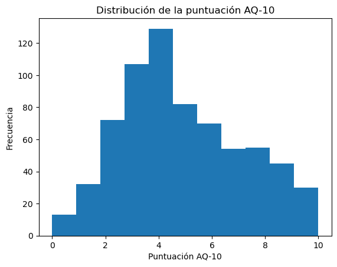

```python
# visualizamos la asimetria positiva de 'result
plt.hist(df['result'], bins=11)  # 11 bins para cada valor posible de 0 a 10
plt.xlabel('Puntuación AQ-10')
plt.ylabel('Frecuencia')
plt.title('Distribución de la puntuación AQ-10')
plt.show()
```

```python
# importamos la libreria 'vega_datasets'
# si no esta instalada, la instalamos
# %pip install altair vega_datasets
```

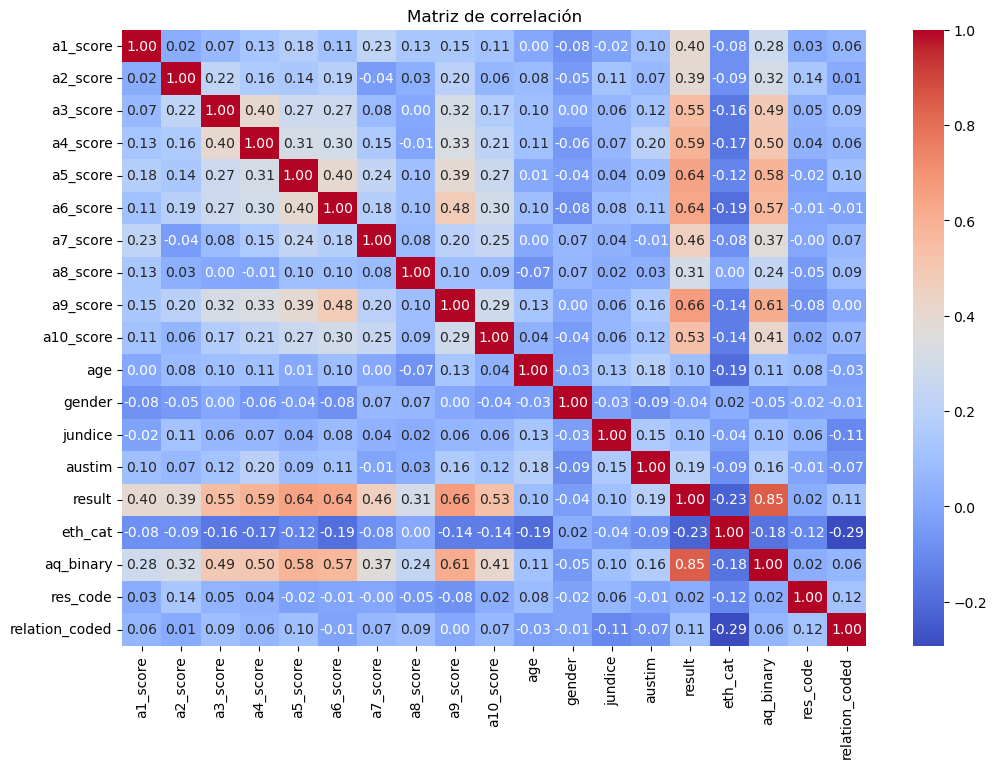

[interactive chart not shown]

```python
# Analisis adicionales (II):
import altair as alt

# 1. Calculamos la matriz de correlación
correlation_matrix = df.corr()

# 2. Creamos un heatmap con Seaborn
plt.figure(figsize=(12, 8))
sns.heatmap(correlation_matrix, annot=True, cmap='coolwarm', fmt=".2f")

# 3. & 4. Mostramos el heatmap con título
plt.title('Matriz de correlación')
plt.show()

# 5. Convertimos el heatmap de Seaborn a un gráfico de Altair
heatmap_data = correlation_matrix.stack().reset_index().rename(
    columns={"level_0": "Variable 1",
             "level_1": "Variable 2",
             0: "Correlación"})

base = alt.Chart(heatmap_data).encode(
    x='Variable 1:O',
    y='Variable 2:O',
    color=alt.Color(
        'Correlación:Q', scale=alt.Scale(
            scheme='blueorange', domain=[-1, 1])),
    tooltip=['Variable 1', 'Variable 2', 'Correlación']
)

# Heatmap
heatmap = base.mark_rect().encode()

# Etiquetas
text = base.mark_text(baseline='middle').encode(
    text=alt.Text('Correlación:Q', format='.2f'),
    color=alt.condition(
        alt.datum.Correlación > 0.5,
        alt.value('white'),
        alt.value('black')
    )
)

# Combinamos heatmap y texto
chart = heatmap + text

# 13. Configuramos el título del gráfico
chart = chart.properties(
    title='Matriz de correlación - Altair',
    width=800,  # Ancho en píxeles
    height=600  # Alto en píxeles
)

# 14. Mostramos el gráfico Altair
chart.show()
```

探索的データ分析により、いくつかの重要な特徴が明らかになりました：

AQ-10 テスト回答の分布:

参加者の大多数は若年成人であり、平均年齢は 29.2 歳でした。 男性 (52.4%) が女性 (47.6%) よりも若干多い、わずかな性別の不均衡が観察されました。 生まれつきの黄疸と自閉症の有病率は低かった（それぞれ 9.7% と 12.9%）。 AQ-10 合計スコア:

AQ-10 の合計スコア (result) の分布は正の歪度を示し、ほとんどの参加者が低いスコアであり、高いスコアのケースは少ないことを示しています。これは、サンプルにおける自閉症の低い有病率と一致しています。 民族性と居住国:

ほとんどの回答は参加者自身によって提供されており、データの信頼性を高めています。 相関行列:

次のセクションでは、さまざまな機械学習モデルを構築して評価します：二値分類 - 線形回帰、および教師なしモデルによってサポートされる多クラス分類。交差検証と適切な評価指標を使用して、モデルのパフォーマンスを比較し、成人における ASD リスクの予測に最適なモデルを選択します。 最も重要なのは、変数が自閉症の診断にどのように影響するかについて、洞察を抽出することです（もしあれば）。 このデータセットは、自閉症ではない個人の割合が高いというクラス不均衡が存在することを認識することが重要です。この不均衡は、モデルのトレーニングと評価の際に、リサンプリングやクラスの重み付けなどの手法を使用して対処し、公平かつ正確なパフォーマンスを確保します。 しかし、サンプルと考慮された変数が完璧なモデルを作成するには不十分である可能性があることも認識されており、ASD 診断の複雑さとさらなる研究の必要性を強調しています。

## 教師なしモデル

教師なしモデルを使用して、データをより深く理解するための探索を行いました。この探索の目的は以下の通りです:

- 表面的な分析では明らかにならないデータ内の潜在的なパターンを発見する。
- 教師ありモデルの予測能力を向上させる可能性のある新しい特徴を生成する。
- データの構造と変数間の関係をよりよく理解する。
- 分類モデルのパフォーマンスを向上させる可能性がある。

### 特徴エンジニアリング

#### 年齢の離散化

年齢は連続的な数値変数であり、自閉症診断との非線形な関係を示す可能性があるため、モデルの予測能力を向上させるために、年齢を区間に分割することにしました。

年齢は四分位数に分割され、データセットの分布に基づいて4つの同サイズのグループに分類されました。この戦略により、成人期の異なる段階での年齢効果を探索することができ、あらかじめ定義された線形関係を仮定せずに分析することが可能になりました。

Pandasの`qcut`関数を使用して離散化を行い、各四分位数に説明的なラベル（Q1, Q2, Q3, Q4）を割り当てました。その後、これらのラベルを機械学習モデルで使用できるように、ラベルエンコーディングを適用して順序付けられた数値に変換しました。

**選択の理由:**

年齢と自閉症の関係について特定の仮説がないため、四分位数での分割が適切と考えられました。関連するカットオフポイントに関する事前情報がない場合、四分位数に分割することで、年齢変数をより柔軟に探索し、連続形式では見られないパターンを発見する可能性が高まります。

**考慮事項:**

- 情報の損失: 年齢を離散化することは、情報の粒度が失われることを意味します。しかし、この損失は非線形な関係を捉える可能性と結果の解釈可能性を向上させることで補われます。
- 影響の評価: この変換がモデルのパフォーマンスに与える影響は、プロジェクトの後続段階で評価されます。

#### K-Meansモデル

```
Puntuación de silueta (K-Means): 0.187503850828204
Índice de Davies-Bouldin (K-Means): 1.977273056530785
Índice de Calinski-Harabasz (K-Means): 150.28624423037508
```

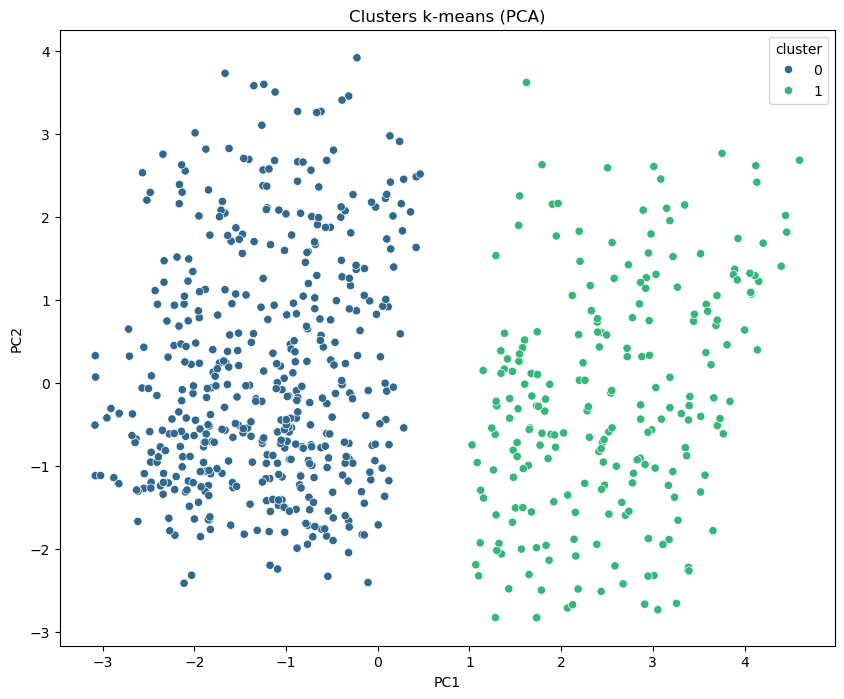

```python
from sklearn.cluster import KMeans
from sklearn.preprocessing import StandardScaler
from sklearn.decomposition import PCA
from sklearn.metrics import (
    silhouette_score, davies_bouldin_score, calinski_harabasz_score)

# importamos el df previamente limpiado
df = pd.read_csv("autism_adult_cleaned.csv")

# Convertimos la edad en cuartiles
df['age_group'] = pd.qcut(df['age'], q=4, labels=['Q1', 'Q2', 'Q3', 'Q4'])

# Codificamos la nueva variable categórica 'age_group'
le = LabelEncoder()
df['age_group_encoded'] = le.fit_transform(df['age_group'])

# visualizamos los valores unicos dentro de la columna 'age_group_encoded'
df['age_group_encoded'].unique()

# eliminamos la columna 'age_group'
df.drop(columns=['age_group'], inplace=True)

# Seleccionamos las caracteristicas:
X = df.drop(columns=['austim', 'result', 'aq_binary'])

# Escalamos las caracteristicas
scaler = StandardScaler()
X_scaled = scaler.fit_transform(X)

# Creamos un modelo KMeans con 2 clusters
kmeans = KMeans(n_clusters=2, random_state=42)
df['k-means'] = kmeans.fit_predict(X_scaled)


# Evaluamos la calidad de los clusters
silhouette_avg = silhouette_score(X_scaled, df['k-means'])
davies_bouldin_index = davies_bouldin_score(X_scaled, df['k-means'])
calinski_harabasz_index = calinski_harabasz_score(X_scaled, df['k-means'])

# Imprimimos los indices
print("Puntuación de silueta (K-Means):", silhouette_avg)
print("Índice de Davies-Bouldin (K-Means):", davies_bouldin_index)
print("Índice de Calinski-Harabasz (K-Means):", calinski_harabasz_index)

# Aplicamos PCA para reducir la dimensionalidad a 2 componentes
pca = PCA(n_components=2)
X_pca = pca.fit_transform(X_scaled)

# Creamos un DataFrame con las componentes
# principales y las etiquetas de los clusters
pca_df = pd.DataFrame(data=X_pca, columns=['PC1', 'PC2'])
pca_df['cluster'] = df['k-means']

# Graficamos los puntos coloreados según el cluster
plt.figure(figsize=(10, 8))
sns.scatterplot(
    x='PC1', y='PC2', hue='cluster', data=pca_df, palette='viridis')
plt.title('Clusters k-means (PCA)')
plt.show()
```

**K-Meansクラスタリングの評価**  
PCAを使用して可視化し、内部メトリクスで評価したk-meansクラスタリングの結果は、データ内に中程度に定義されたクラスタ構造を示しました。

- シルエットスコア: 0.188という値は、クラスタ間の分離が適度に行われていることを示しており、多少の重なりがありました。これは、クラスタ内である程度の一貫性があり、識別可能であるものの、それほど顕著ではないことを示唆しています。
- デービス-ボウディン指数: 1.98という値は、前述の観察を裏付けています。この指数はクラスタ間の類似性を測定し、グループ間に中程度の分離があることを示しており、一部のクラスタが近接しているか、重なっている可能性があることを示しています。
- カリンスキー-ハラバス指数: 150.29という値は、クラスタリングの品質が良好であることを示唆しています。この指数は密集してよく分離されたクラスタを好むため、この値は合理的なクラスタ構造を示しています。

**散布図 (PCA):**

全体として、k-meansアルゴリズムはデータ内で2つのクラスタを識別することができましたが、それらの分離は完璧ではありませんでした。これは、データの性質、特徴の選択、または自閉症検出の問題に内在する複雑さに起因する可能性があります。

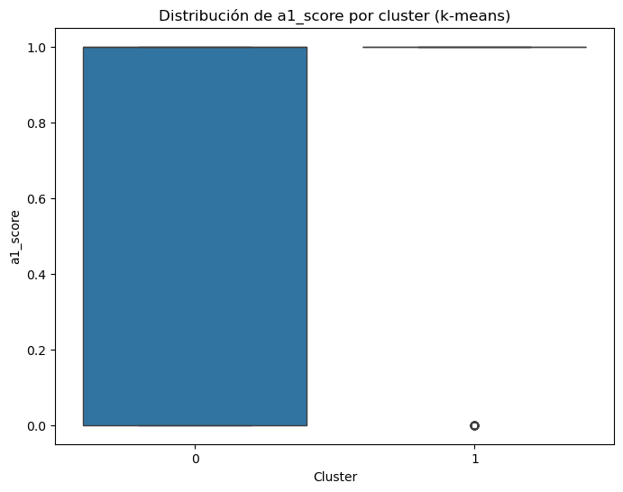

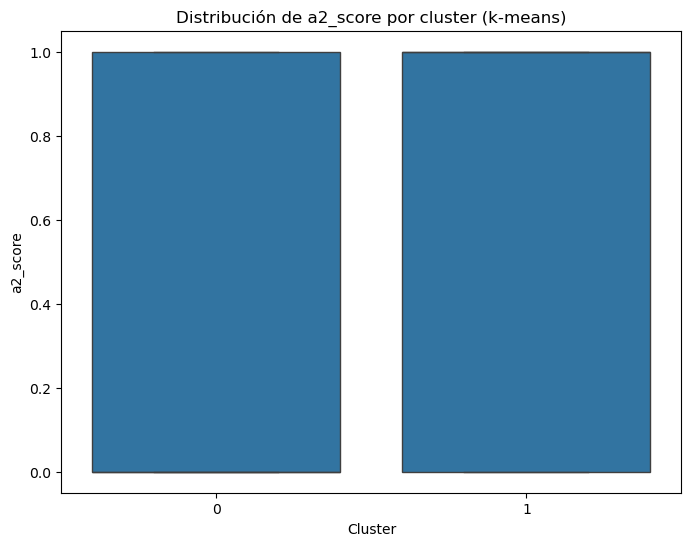

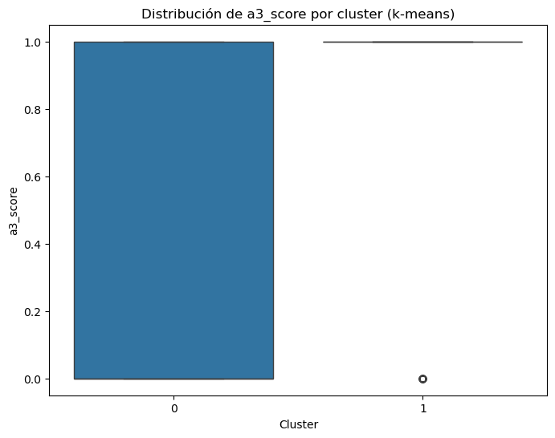

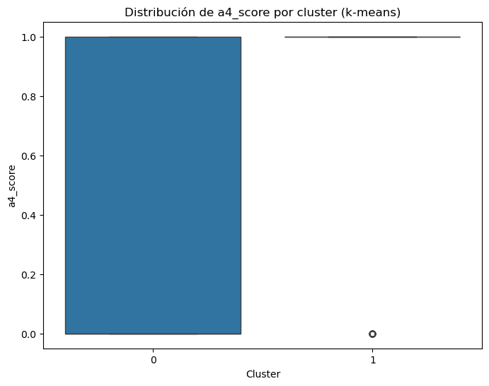

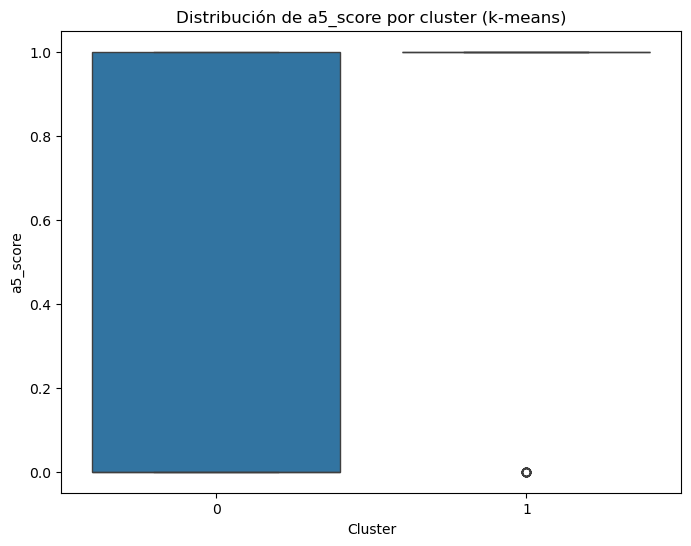

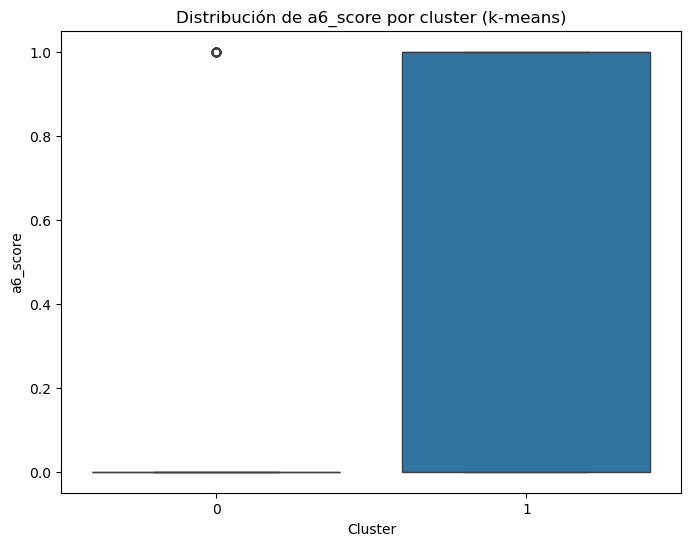

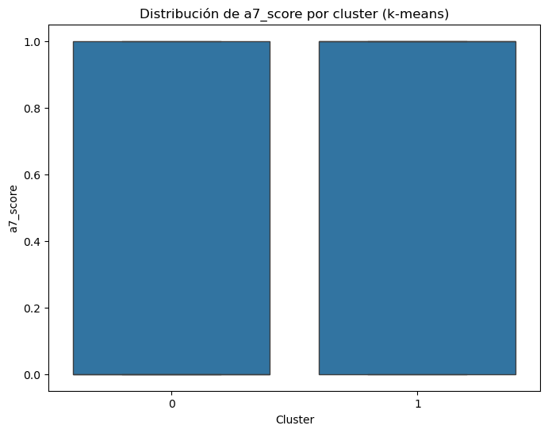

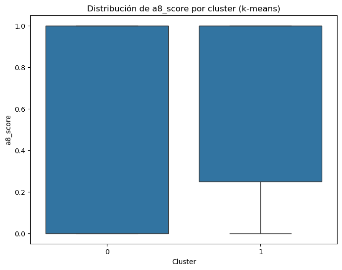

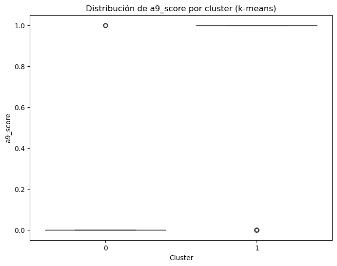

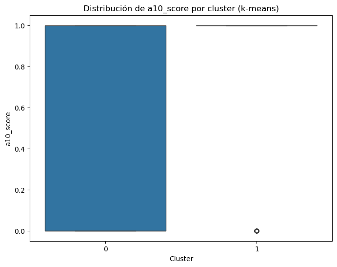

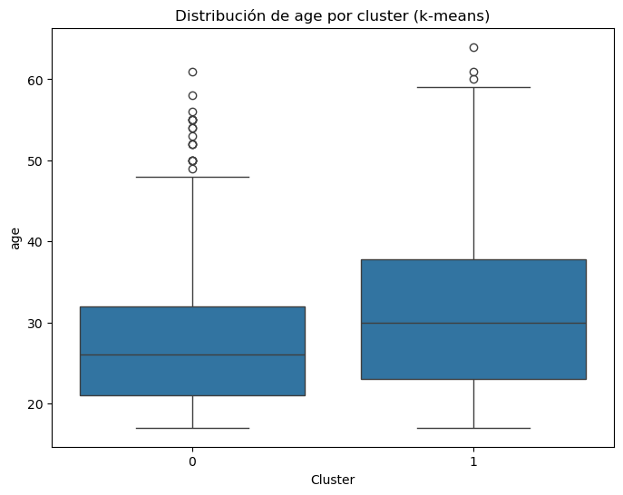

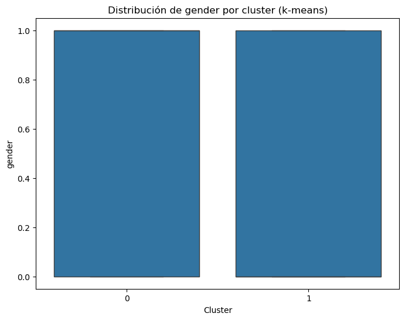

[5 more figures not shown]

```python
# Graficamos la distribución de las
# variables a los clusters:
import seaborn as sns
import matplotlib.pyplot as plt

# Convertimos X_scaled a DataFrame
X_scaled_df = pd.DataFrame(X_scaled, columns=X.columns)
# Iteramos sobre las columnas numéricas
# escaladas para visualizar los clusters
for col in X_scaled_df.columns:
    # Verificamos si la columna es numérica (int64)
    if df[col].dtype == 'int64':
        plt.figure(figsize=(8, 6))
        sns.boxplot(x='k-means', y=col, data=df)
        plt.title(f'Distribución de {col} por cluster (k-means)')
        plt.xlabel('Cluster')
        plt.ylabel(col)
        plt.show()
```

**クラスター形成における特徴の関連性分析**  
k-means クラスタリング技術を用いた探索的データ分析（EDA）により、識別された2つのクラスターの形成に対する各特徴の寄与度を評価することができました。

**AQスコア**  
特に、a7_scoreとa2_scoreの変数が両クラスターにわたってほぼ同一の分布を示していることが観察されました。これは、これらの特徴がグループ間を区別するための識別情報を提供していないことを示唆しています。クラスター間でのこれらの変数の変動性の欠如は、k-meansがクラスタリングに使用した基礎的なパターンと関連していないことを示しています。

**性別**  
同様に、性別変数の分析では、両クラスターで男性と女性の分布が類似していることが明らかになりました。これは、このデータセットの文脈において、性別がクラスター形成や自閉症スペクトラム障害（ASD）の発現に関連する要因ではないことを示唆しています。

**居住国**  
k平均法におけるクラスタごとの res_code（居住国コード）の分布を示す箱ひげ図の分析から、居住地はクラスタ形成の決定要因ではないと考えられました。

類似した分布:

両クラスタの中央値と四分位範囲は非常に似ており、国コードの分布は両グループで実質的に同じであることを示しています。

外れ値に識別可能なパターンなし:

両クラスタにいくつかの外れ値が観察されましたが、特定の国と特定のクラスタとの関連性を示唆する明確なパターンは確認されませんでした。

res_code の分布が両クラスタで非常に似ていたことから、居住地はk平均法によるグループ形成において識別的な役割を果たさず、この変数は識別された2つのクラスタを区別するための有意な情報を提供しないという結論に至りました。

**黄疸**  
jundice の場合も、黄疸は必ずしも自閉スペクトラム症と関連しているようには見えないと結論付けられます。

ほとんどの値が両方のクラスタで0: 両方の箱の中央線は0の位置にあり、これは両方のクラスタのほとんどの個体が0の値を持っていることを意味します。

**年齢（スケールなし）**  
変数 age （離散化されていない）は、k平均法によって生成された2つのクラスタ間である程度の識別能力を持っているように見えます。

クラスタ1の中央値が高い: 箱の中の線（中央値）は、クラスタ0よりもクラスタ1の方が明らかに高くなっています。これは、クラスタ1の個体の典型的な年齢が、クラスタ0の個体よりも高いことを示しています。

**民族性**  
民族性（eth_cat）は、2つのグループ間で民族カテゴリの分布に明確な違いがあることから、クラスタ形成に影響を与える要因のようです。

クラスタ0: 主に白人。

クラスタ1: より民族的に多様で、少数民族または「その他」のカテゴリに分類される個人の割合が高い。

潜在的な予測因子: 民族性は、自閉症リスクに影響を与える遺伝的、環境的、または社会文化的要因と関連している可能性があります。モデルの特徴として民族性を含めることで、これらの違いを捉え、予測能力を向上させることができます。

格差の特定: 民族性と自閉症の関係を分析することで、異なる民族グループ間における障害の有病率または診断における潜在的な格差を特定するのに役立ちます。これは、より公平な介入と支援戦略を開発するために役立ちます。

***関係*** `relation_coded`変数のコーディングに基づくと:

*0: 親 1: 親戚 2: 自分自身* 棒グラフの分析は、k-meansにおけるrelation_codedのクラスターごとの分布を示しています。 結論として、以下のことが言えます。

**クラスター0:** 回答が「自分自身」または「親戚」によって提供された個人が混在しています。 **クラスター1:** ほぼ全ての回答が「自分自身」によって提供された個人で構成されています。 したがって、k-meansは診断時に1人で来院した大多数の個人をクラスター1にグループ化していることがわかります。

影響:

クラスター1の大多数の個人が1人で来院しているということは、次のことを示唆している可能性があります。

- 自閉症に対する意識や関心の向上: これらの個人は、自分の特性や困難についての意識が高く、自ら積極的に評価を受けようとしている可能性があります。
- より高い自律性: これらの個人は、情報や支援を自ら探し求める独立性の高い人々である可能性があります。
- 診断に対するスティグマや恐怖の減少: 1人で来院することは、自閉症に対するスティグマへの関心が低いか、明確な診断を求める意欲が強いことを示している可能性があります。

他の解釈の可能性:

- 社会的相互作用の困難: 場合によっては、自閉症の人々は社会的相互作用や効果的なコミュニケーションが難しいことがあり、そのため1人で来院することを好むかもしれません。
- 家族の支援の欠如: 他のケースでは、家族からの支援や理解が不足しているため、自ら助けを求めに来る場合も考えられます。

物流的要因: また、交通手段の利用可能性や他の家族の世話をする必要性など、物流的な要因が診療所に1人で行く決断に影響を与えた可能性もあります。

これらの影響を考慮することの重要性:

これらの解釈の可能性を考慮しながら、モデルの結果を分析し、`relation_coded`変数を予測変数として含めることを検討することが重要です。

- 意識や関心の向上の仮説が正しい場合: モデルは自閉症そのものを特定するのではなく、支援を求めようとする意欲が高い人々や自閉症に関する知識が豊富な人々を特定している可能性があります。
- 社会的相互作用の困難の仮説が正しい場合: モデルは社会的相互作用に関連する自閉症の特定の側面を捉えている可能性があります。
- 家族の支援の欠如の仮説が正しい場合: モデルは、自閉症と関連する可能性がある社会経済的または家族的な要因を間接的に特定していることを示唆している可能性があります。

***年齢（離散化）*** 年齢は、離散化された場合でも、クラスタリング過程で役割を果たしているように見えます。K-meansは年齢グループに基づいて個人を部分的に分離しており、クラスター0は若い個人に、クラスター1は年配の個人に傾向があります。

- 唯一の要因ではない：クラスター間の年齢分布の重複は、年齢以外の要因もクラスターの形成に寄与していることを示しています。

考えられる意味：

- 自閉症の年齢関連パターン：これは、あなたのデータセット内で自閉症に関連する特性に年齢関連のパターンや違いがある可能性を示唆しています。

クラスタ間の区別に情報を提供しない特徴を残しておくと、モデルにノイズが入り、パフォーマンスに悪影響を与える可能性があります。そのため、必要のない特徴を削除することにしました。

```python
# eliminamos columnas
df.drop(columns=['a7_score', 'a2_score', 'gender', 'res_code', 'jundice'],
        inplace=True)
# Revisamos el dataframe
df.info()
```

[output not shown]

```
Puntuación de silueta (K-Means): 0.187503850828204
Índice de Davies-Bouldin (K-Means): 1.977273056530785
Índice de Calinski-Harabasz (K-Means): 150.28624423037508
```

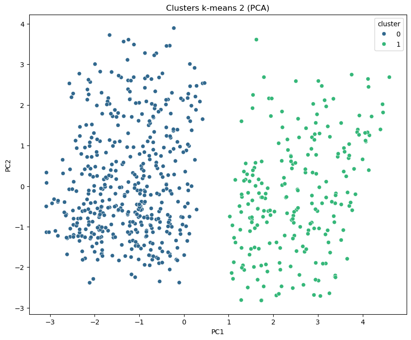

```python
from sklearn.decomposition import PCA
import matplotlib.pyplot as plt

# Creamos un modelo KMeans con 2 clusters,
# Usando k-means++ para la inicialización
kmeans = KMeans(n_clusters=2, init='k-means++', random_state=42)
df['k-means2'] = kmeans.fit_predict(X_scaled)

# Evaluamos la calidad de los clusters
silhouette_avg = silhouette_score(X_scaled, df['k-means2'])
davies_bouldin_index = davies_bouldin_score(X_scaled, df['k-means2'])
calinski_harabasz_index = calinski_harabasz_score(X_scaled, df['k-means2'])

# Imprimimos los indices
print("Puntuación de silueta (K-Means):", silhouette_avg)
print("Índice de Davies-Bouldin (K-Means):", davies_bouldin_index)
print("Índice de Calinski-Harabasz (K-Means):", calinski_harabasz_index)


# Aplicamos PCA para reducir la dimensionalidad a 2 componentes
pca = PCA(n_components=2)
X_pca = pca.fit_transform(X_scaled)

# Creamos un DataFrame con las componentes
# principales y las etiquetas de los clusters
pca_df = pd.DataFrame(data=X_pca, columns=['PC1', 'PC2'])
pca_df['cluster'] = df['k-means2']

# Graficamos los puntos coloreados según el cluster
plt.figure(figsize=(10, 8))
sns.scatterplot(
    x='PC1', y='PC2', hue='cluster', data=pca_df, palette='viridis')
plt.title('Clusters k-means 2 (PCA)')
plt.show()
```

```python
# Eliminamos la columna K-means2
df.drop(columns = ['k-means2'], inplace = True)
```

#### DBSCAN および OPTICS モデル

密度に基づく教師なしクラスタリングモデル、DBSCAN（Density-Based Spatial Clustering of Applications with Noise）とOPTICS（Ordering Points To Identify the Clustering Structure）は、データ分析の潜在的な代替手段として検討されました。これらのモデルは、セントロイドベースで球状のクラスタ形状を前提とする k-means とは異なり、特徴空間における点の密度に基づいてグループを識別するため、任意の形状のクラスタを発見し、ノイズを含むデータをより効果的に処理することができます。

```python
from sklearn.cluster import DBSCAN

# Salvamos el dataset
df.to_csv('autism_adult_kmeans.csv', index=False)

# Cargamos el dataset por cuestiones de indices:
df = pd.read_csv('autism_adult_kmeans.csv')

# Aplicamos DBSCAN con un epsilon de 0.9
# y min_samples de 2
dbscan = DBSCAN(eps=0.9, min_samples=1)
df['dbscan'] = dbscan.fit_predict(X_scaled)

# Evaluamos la calidad de los clusters
silhouette_avg = silhouette_score(X_scaled, df['dbscan'])
davies_bouldin_index = davies_bouldin_score(X_scaled, df['dbscan'])
calinski_harabasz_index = calinski_harabasz_score(X_scaled, df['dbscan'])

# Imprimimos los resultados
print("Puntuación de silueta (DBSCAN):", silhouette_avg)
print("Índice de Davies-Bouldin (DBSCAN):", davies_bouldin_index)
print("Índice de Calinski-Harabasz (DBSCAN):", calinski_harabasz_index)
```

```
Puntuación de silueta (DBSCAN): 0.04753146192306328
Índice de Davies-Bouldin (DBSCAN): 0.11009453822449286
Índice de Calinski-Harabasz (DBSCAN): 103.97360322975021
```

PCAを適用して次元数を2つのコンポーネントに削減しました。ただし、K-Meansの結果によると、2つのクラスタにグループ化される傾向があることがわかっています。

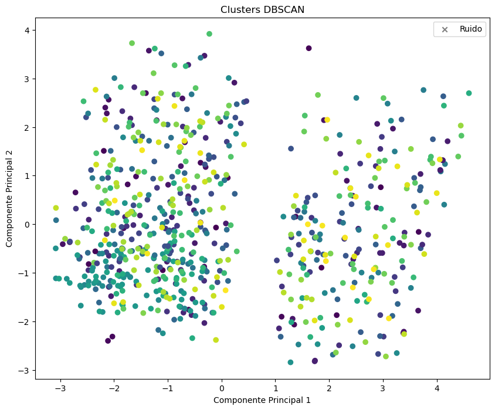

```python
import matplotlib.pyplot as plt
from sklearn.decomposition import PCA
import numpy as np

# Aplicamos PCA
pca = PCA(n_components=2)
X_pca = pca.fit_transform(X_scaled)

# Crear el gráfico de dispersión
plt.figure(figsize=(10, 8))
plt.scatter(
    X_pca[:, 0], X_pca[:, 1], c=df['dbscan'], cmap='viridis', marker='o')
plt.scatter(X_pca[df['dbscan'] ==
            -1, 0], X_pca[df['dbscan'] ==
                          -1, 1], c='gray', marker='x', label='Ruido')
plt.xlabel('Componente Principal 1')
plt.ylabel('Componente Principal 2')
plt.title('Clusters DBSCAN')
plt.legend()
plt.show()
```

散布図は、DBSCAN が 様々なハイパーパラメータ を設定した後でも、データ内に明確なクラスタ構造を見つけられなかったことを示唆していました。 そこで、OPTICS を試してみました。

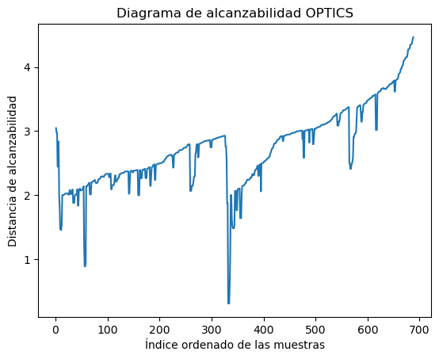

```python
from sklearn.cluster import OPTICS
import matplotlib.pyplot as plt

# Aplicamos OPTICS
optics = OPTICS(min_samples=4, xi=0.05, min_cluster_size=0.05)
df['optics'] = optics.fit_predict(X_scaled)

# Obtenemos las distancias de alcanzabilidad y ordenarlas
reachability = optics.reachability_[optics.ordering_]

# Graficamos el diagrama de alcanzabilidad
plt.plot(reachability)
plt.xlabel('Índice ordenado de las muestras')
plt.ylabel('Distancia de alcanzabilidad')
plt.title('Diagrama de alcanzabilidad OPTICS')
plt.show()
```

***OPTICS到達可能性ダイアグラムの分析*** OPTICSによって生成された到達可能性ダイアグラムは、データの基礎となる密度構造に関する重要な情報を明らかにします。このグラフでは、各点がサンプルとその到達可能距離を表しており、これはその点がデータセット内の他の点に対してどれだけ近いかを、近隣の密度を考慮して示しています。

***主な観察点***

- クラスタリングの証拠: 最初は単一の支配的なクラスターがあるという印象を受けるかもしれませんが、グラフの前半部分にはいくつかの急な谷が見られます。これらの谷は、比較的高密度の複数のクラスターが存在し、低密度の領域（ピーク）で分かれていることを示唆しています。
- 支配的なクラスターとノイズの可能性: グラフの終わりに向かって到達可能距離が大幅に増加し、曲線が滑らかになり、急な谷が減少します。これは、大きくて密度の低いクラスターの存在、またはノイズや外れ値の存在を示している可能性があります。
- 外れ値の可能性: 谷から高くそびえる孤立したピークは、他の点から比較的遠く、密集したクラスターに属さない外れ値を表している可能性があります。

***考えられる結論***

- クラスター構造: データはクラスター構造を示しているようで、グラフの前半部分には複数の小さくて密度の高いクラスターがあり、後半部分にはより大きくて密度の低いクラスターまたはノイズが存在する可能性があります。
- クラスターの数の推定: 正確なクラスター数を視覚的に判断するのは難しいですが、最も顕著な谷に基づいて3から5の主要なクラスターが存在すると推定されます。最終的な選択は、分析の目的や問題の文脈に依存します。
- ノイズの存在: グラフ内の孤立したピークは、データ内にノイズや外れ値が存在する可能性を示唆しています。

クラスターを抽出します:

```python
from sklearn.cluster import cluster_optics_dbscan
from sklearn.metrics import silhouette_score

# Extraemos clusters utilizando extract_dbscan
labels = cluster_optics_dbscan(reachability=optics.reachability_,
                               core_distances=optics.core_distances_,
                               ordering=optics.ordering_, eps=0.5)

# Asignamos las etiquetas de cluster al DataFrame
df['cluster_optics'] = labels

# Calculamos la puntuación de silueta
# silhouette_avg = silhouette_score(X_scaled, labels)
# print("Puntuación de silueta:", silhouette_avg)

# Evaluamos la calidad de los clusters
silhouette_avg = silhouette_score(X_scaled, labels)
davies_bouldin_index = davies_bouldin_score(X_scaled, labels)
calinski_harabasz_index = calinski_harabasz_score(X_scaled, labels)

# Imprimimos los resultados
print("Puntuación de silueta (OPTICS):", silhouette_avg)
print("Índice de Davies-Bouldin (OPTICS):", davies_bouldin_index)
print("Índice de Calinski-Harabasz (OPTICS):", calinski_harabasz_index)
```

```
Puntuación de silueta (OPTICS): 0.04009793968428268
Índice de Davies-Bouldin (OPTICS): 0.918096842270528
Índice de Calinski-Harabasz (OPTICS): 4.98007764446465
```

シルエットスコアが0.040というのは非常に低い値であり、OPTICS で得られたクラスタが明確に定義されておらず、おそらくそれらの間には大きな重複があることを示しています。k-means がより明確に分離された2つのクラスタを識別できたことを考慮すると、OPTICS はこの特定のデータセットには最適なアルゴリズムではないと結論付けるのが妥当と思われます。

結果が不満足で将来のモデルを混乱させる可能性のある dbscan と optics からの列を削除しました。

```python
# Eliminamos columnas
df.drop(columns=['dbscan', 'optics'], inplace=True)
print(df.columns)
```

```
Index(['a1_score', 'a3_score', 'a4_score', 'a5_score', 'a6_score', 'a8_score',
       'a9_score', 'a10_score', 'age', 'austim', 'result', 'eth_cat',
       'aq_binary', 'relation_coded', 'age_group_encoded', 'k-means',
       'cluster_optics'],
      dtype='object')
```

```python
# Observamos el estado general
df.info()
```

```
<class 'pandas.core.frame.DataFrame'>
RangeIndex: 689 entries, 0 to 688
Data columns (total 17 columns):
 #   Column             Non-Null Count  Dtype
---  ------             --------------  -----
 0   a1_score           689 non-null    int64
 1   a3_score           689 non-null    int64
 2   a4_score           689 non-null    int64
 3   a5_score           689 non-null    int64
 4   a6_score           689 non-null    int64
 5   a8_score           689 non-null    int64
 6   a9_score           689 non-null    int64
 7   a10_score          689 non-null    int64
 8   age                689 non-null    int64
 9   austim             689 non-null    int64
 10  result             689 non-null    int64
 11  eth_cat            689 non-null    int64
 12  aq_binary          689 non-null    int64
 13  relation_coded     689 non-null    int64
 14  age_group_encoded  689 non-null    int64
 15  k-means            689 non-null    int64
 16  cluster_optics     689 non-null    int64
dtypes: int64(17)
memory usage: 91.6 KB
```

#### 探索的データ分析（EDA）とデータ品質保証（DQA）（II）

***特徴の探索を深める***

EDAとDQAの第一段階を経て、データ構造と変数間の関係について新たな知見を得た後、探索的分析の第二段階に進みます。この段階では、個々の特性とそれらの自閉症予測における可能な関連性の理解を深めることに焦点を当てます。

***クラスタリングにおける年齢の要因***

上記で得られたボックスプロットのみに基づいて、年齢は2つのクラスターを分離する上でいくらかの識別力を持っていますが、非常に強力な分類器ではないと言えます。中央値のわずかな違いとクラスター0における外れ値の存在は、年齢がクラスタリングにおいて役割を果たしている可能性を示していますが、それが唯一の、あるいは支配的な要因である可能性は低いです。

- 中央年齢の差：

中央年齢（各ボックス内の水平線で表される）は、クラスター0と比較してクラスター1でわずかに高くなっています。これは、平均して、**クラスター1の個人がクラスター0の個人よりも年上である傾向**を示唆しています。

- 四分位範囲（IQR）：

IQR（各ボックスの高さ）は視覚的に両クラスター間で似ており、各クラスター内の年齢の広がりや変動性がほぼ同等であることを示しています。

**民族性とクラスタリングの関係:**  
年齢と同様に、民族性もまたクラスタ形成に影響を与える要因であると考えられます。2つのグループ間で民族カテゴリの分布に明確な違いが見られるからです。

クラスタ0: 主に白人。

クラスタ1: より民族的に多様で、少数民族または「その他」のカテゴリに分類される個人の割合が高い。

民族性は、教師あり学習モデルにおいて以下の点で役立つ可能性があります:

潜在的な予測因子: 民族性は、自閉症のリスクに影響を与える遺伝的、環境的、または社会文化的要因と関連している可能性があります。モデルの特徴として民族性を含めることで、これらの違いを捉え、予測能力を向上させることができます。 格差の特定: 民族性と自閉症の関係を分析することで、異なる民族グループ間におけるこの障害の有病率または診断における潜在的な格差を特定するのに役立ちます。これは、より公平な介入と支援戦略を開発するために価値があります。

##### 民族性と自閉症の関係を深める

1. 分割表:

```python
from scipy.stats import chi2_contingency

# Creamos una tabla de contingencia entre 'eth_cat' y 'austim'
contingency_table = pd.crosstab(df['eth_cat'], df['austim'])
# Realizamos la prueba de chi-cuadrado
chi2, p_value, _, _ = chi2_contingency(contingency_table)

# Calculamos el coeficiente V de Cramer
# Número total de observaciones
n = contingency_table.sum().sum()
phi2 = chi2 / n
# Número de filas o columnas - 1
k = min(contingency_table.shape[0], contingency_table.shape[1]) - 1
cramer_v = np.sqrt(phi2 / k)

print("Tabla de contingencia:\n", contingency_table.to_markdown(numalign="left", stralign="left"))
print(f"Estadístico chi-cuadrado: {chi2}, Valor p: {p_value}")
print(f"Coeficiente V de Cramer: {cramer_v}")
```

```
16:80: E501 line too long (98 > 79 characters)
```

```
Tabla de contingencia:
 | eth_cat   | 0   | 1   |
|:----------|:----|:----|
| 1         | 181 | 50  |
| 2         | 118 | 4   |
| 3         | 81  | 8   |
| 4         | 37  | 5   |
| 5         | 34  | 2   |
| 6         | 22  | 9   |
| 7         | 127 | 11  |
Estadístico chi-cuadrado: 38.87068852299217, Valor p: 7.587695260596013e-07
Coeficiente V de Cramer: 0.23752072256395562
```

```python
# convertimos la notacion cientifica a decimal
num_decimal: float = float(p_value)
print(f"Valor p: {num_decimal:.20f}")
```

```
Valor p: 0.00000075876952605960
```

***対応表分析:***

対応表と関連するp値は、民族性（eth_cat）と自閉症診断（austim）の間に統計的に有意な関連があることを示しています。

- p値: p値は非常に小さく（7.58e-07）、通常の有意水準である0.05を大きく下回っています。これは、**民族性と自閉症の間に観察された関連が偶然によるものではない可能性が非常に高い**ことを示しています。
- 解釈: このサンプルにおいて、民族性と自閉症の間に関連がないという**帰無仮説を棄却するための十分な証拠がある**と結論できます。民族性はこのデータセットにおける自閉症の診断と関連しているようです。
- 関連の強さ: Cramer's V係数

カテゴリ変数間の関連の強さを測定するCramer's V係数は0.238と計算されました。この値は、このサンプルにおける民族性と自閉症の間に**低から中程度の関連**があることを示唆しています。

制限事項:

カイ二乗検定とCramer's V係数は、関連の存在とその強さについて教えてくれますが、この関係の性質や方向性については明らかにしてくれません。より深い理解のためには、対応表を慎重に調べ、関連に影響を与えている可能性のある他の要因も考慮する必要があります。

今後の分析に対する推奨事項:

- 残差分析: 対応表の標準化残差を調べることで、統計的有意性に最も寄与しているセル、つまり観察された関連に寄与しているセルを特定するのに役立ちます。
- 交絡因子の制御: 民族性や自閉症診断の両方に影響を与える可能性のある他の要因（例えば、社会経済的地位や医療サービスへのアクセス）によって、偽の関連が生じている可能性があります。これらの変数を制御する追加の分析を行うことで、民族性と自閉症の関連が持続するかどうかを評価することが推奨されます。
- 縦断研究: 因果関係を確立するためには、時間の経過とともに個人を追跡し、民族性や他の要因が自閉症の発症と診断にどのように相互作用するかを評価する縦断研究が必要です。

統計的関連が**因果関係を意味しない**ことを常に念頭に置くことが重要です。民族性は実際には自閉症と関連する他の根底にある要因の指標である可能性があります。

2. 比率の比較:

**ETH_CAT**

```python
# Contamos el número de individuos por etnia
ethnicity_counts = df['eth_cat'].value_counts().sort_index()

print("Conteo de individuos por etnia:\n",
      ethnicity_counts.to_markdown(numalign="left", stralign="left"))
```

```
Conteo de individuos por etnia:
 | eth_cat   | count   |
|:----------|:--------|
| 1         | 231     |
| 2         | 122     |
| 3         | 89      |
| 4         | 42      |
| 5         | 36      |
| 6         | 31      |
| 7         | 138     |
```

```python
# Calculamos la proporción (medias) de autismo por etnia
autism_proportions = df.groupby('eth_cat')['austim'].mean()

print("Proporción de autismo (medias) por etnia:\n", autism_proportions.to_markdown(numalign="left", stralign="left", floatfmt='.2f'))
```

```
Proporción de autismo (medias) por etnia:
 | eth_cat   | austim   |
|:----------|:---------|
| 1         | 0.22     |
| 2         | 0.03     |
| 3         | 0.09     |
| 4         | 0.12     |
| 5         | 0.06     |
| 6         | 0.29     |
| 7         | 0.08     |
```

```python
# Calculamos el número de individuos con autismo por etnia
autism_counts_by_ethnicity = df[df['austim'] == \
1]['eth_cat'].value_counts().sort_index()

# Calculamos el porcentaje de autismo por etnia
percentage_autism_by_ethnicity =\
(autism_counts_by_ethnicity / ethnicity_counts) * 100

print("Porcentaje de autismo por etnia:\n",
      percentage_autism_by_ethnicity.to_markdown(numalign="left",
                                                 stralign="left", floatfmt='.2f'))
```

```
Porcentaje de autismo por etnia:
 | eth_cat   | count   |
|:----------|:--------|
| 1         | 21.65   |
| 2         | 3.28    |
| 3         | 8.99    |
| 4         | 11.90   |
| 5         | 5.56    |
| 6         | 29.03   |
| 7         | 7.97    |
```

```python
# Calculamos el número total de individuos diagnosticados con autismo
total_autism = df['austim'].sum()

# Calculamos el número de individuos con autismo por etnia
autism_counts_by_ethnicity = \
    df[df['austim'] == 1]['eth_cat'].value_counts().sort_index()

# Calculamos el porcentaje del total de diagnosticados por etnia
percentage_autism_by_ethnicity_total = \
    (autism_counts_by_ethnicity / total_autism) * 100

print("Porcentaje del total de diagnosticados por etnia:\n",
      percentage_autism_by_ethnicity_total.to_markdown(
          numalign="left", stralign="left", floatfmt='.2f'))
```

```
Porcentaje del total de diagnosticados por etnia:
 | eth_cat   | count   |
|:----------|:--------|
| 1         | 56.18   |
| 2         | 4.49    |
| 3         | 8.99    |
| 4         | 5.62    |
| 5         | 2.25    |
| 6         | 10.11   |
| 7         | 12.36   |
```

***比率比較の分析：*** 画像には、データセット内の異なる民族カテゴリーにおける自閉症診断の分布に関する情報を提供する2つの表が示されています。

1. 表2：「民族別自閉症割合」

この表は、各民族カテゴリー内で自閉症と診断された個人の割合を示しています。

- 主な観察結果： 「ラテン系」カテゴリーが最も高い自閉症診断率（29.03％）を示しており、このサンプル内でこのグループにおける自閉症の過剰表現の可能性を示唆しています。 「アジア系」カテゴリーが最も低い割合（3.28％）を示しており、過小表現の可能性を示しています。 その他のカテゴリーは様々な割合を示しており、「その他」が7.97％、「黒人」が11.90％となっています。
2. 表3：「民族別の総診断数に対する割合」

この表は、データセット内の自閉症診断の総数に対する各民族カテゴリーの寄与率を示しています。

**ETH_CAT**

```python
# Volvemos a recrear un diccionario con las etiquetas de etnia
# posiblemente no necesitemos esto
eth_map = {
    "White": 1,
    "Asian": 2,
    "Middle Eastern": 3,
    "Black": 4,
    "South Asian": 5,
    "Latin": 6,
    "Others": 7
}
# Creamos un diccionario inverso para
# mapear los códigos a los nombres de las etnias
inverse_eth_map = {v: k for k, v in eth_map.items()}

# Mapeamos los índices (códigos) de la serie a los nombres de las etnias
ethnicity_labels = percentage_autism_by_ethnicity.index.map(inverse_eth_map)

print(inverse_eth_map)
```

```
{1: 'White', 2: 'Asian', 3: 'Middle Eastern', 4: 'Black', 5: 'South Asian', 6: 'Latin', 7: 'Others'}
```

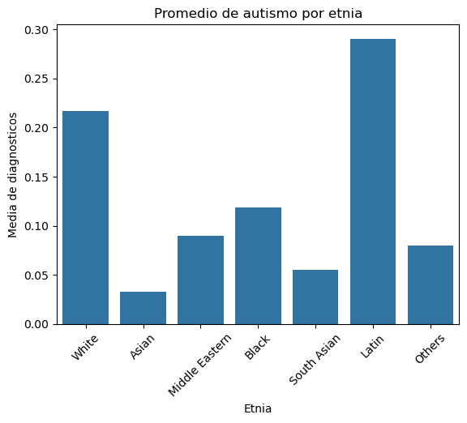

```python
import seaborn as sns

# Gráfico de barras de la proporción de autismo por etnia
sns.barplot(x=ethnicity_labels, y=autism_proportions.values)
plt.xlabel('Etnia')
plt.ylabel('Media de diagnosticos')
plt.title('Promedio de autismo por etnia')
plt.xticks(rotation=45)
plt.show()
```

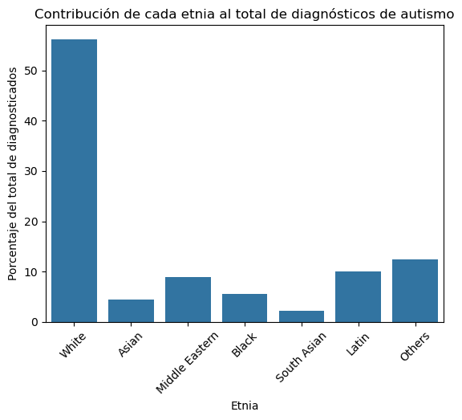

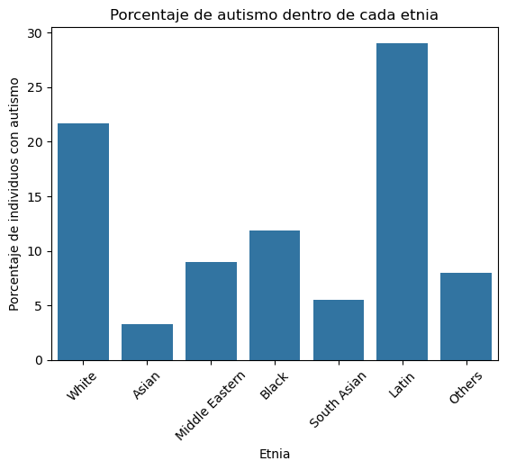

```python
# Mapeamos los índices (códigos) de la serie a los nombres de las etnias
ethnicity_labels = percentage_autism_by_ethnicity.index.map(inverse_eth_map)
ethnicity_labels_total =\
    percentage_autism_by_ethnicity_total.index.map(inverse_eth_map)

# Gráfico de barras del porcentaje de autismo por etnia del total
sns.barplot(x=ethnicity_labels_total,
            y=percentage_autism_by_ethnicity_total.values)
plt.xlabel('Etnia')
plt.ylabel('Porcentaje del total de diagnosticados')
plt.title('Contribución de cada etnia al total de diagnósticos de autismo')
plt.xticks(rotation=45)
plt.show()

# Gráfico de barras del porcentaje de autismo por etnia
sns.barplot(x=ethnicity_labels, y=percentage_autism_by_ethnicity.values)
plt.xlabel('Etnia')
plt.ylabel('Porcentaje de individuos con autismo')
plt.title('Porcentaje de autismo dentro de cada etnia')
plt.xticks(rotation=45)
plt.show()
```

4. ロジスティック回帰分析:

***ETH_CAT***

```python
import statsmodels.api as sm
from sklearn.linear_model import LogisticRegression

# Creamos un modelo de regresión logística con 'eth_cat' como predictor
model_log_reg = LogisticRegression()
model_log_reg .fit(df[['eth_cat']], df['austim'])

# Usamos statsmodels para obtener los valores p
# Agregamos una constante para el término de intersección
X = sm.add_constant(df[['eth_cat']])
logit_model = sm.Logit(df['austim'], X)
result = logit_model.fit()
p_values = result.pvalues

# Obtenemos los coeficientes y el valor p de la
# la edad codificada
eth_coef = model_log_reg.coef_[0][0]
eth_p_value = p_values['eth_cat']

print(f"Coeficiente de la etnia: {eth_coef}, Valor p: {eth_p_value}")
# Otras estadisticas relevantes
print("Pseudo R-cuadrado:", result.prsquared)
print("Log-likelihood:", result.llf)
print("AIC:", result.aic)
print("BIC:", result.bic)
```

```
Optimization terminated successfully.
         Current function value: 0.380804
         Iterations 6
Coeficiente de la etnia: -0.12165561018051915, Valor p: 0.02312216197463547
Pseudo R-cuadrado: 0.01041187415578626
Log-likelihood: -262.3742554755308
AIC: 528.7485109510616
BIC: 537.8189934930889
```

```python
# convertimos la notacion cientifica a decimal
num_decimal: float = float(eth_p_value)
print(f"Valor p: {num_decimal:.20f}")
```

```
Valor p: 0.02312216197463546827
```

**民族に関する線形ロジスティック回帰の結果の解釈:**

***民族と自閉症診断の関係の分析***

探索的データ分析（EDA）により、調査対象のサンプルにおける民族と自閉症スペクトラム障害（ASD）の診断との関連を検討しました。この関係を評価するために、以下の2つの補完的なアプローチが使用されました:

1. 民族ごとの自閉症の割合:

2. 各民族が全体の診断数に占める割合:

カイ二乗検定とCramer's V係数:

民族と自閉症の間の関連の統計的有意性を評価するためにカイ二乗検定を実施しました。得られたp値（7.58e-07）は、通常の有意水準0.05を大幅に下回っており、両変数の間に統計的に有意な関連があることを示しています。

解釈:

結果は、調査対象のサンプルにおいて民族と自閉症診断の間に関連がある可能性を示唆しています。ただし、次の点を考慮して、これらの結果を慎重に解釈する必要があります:

- 相関 vs. 因果関係: 観察された統計的関連は、必ずしも民族と自閉症の間に直接的な因果関係があることを意味しません。民族と診断の両方に影響を与える社会経済的または文化的な違いなど、他の要因が存在する可能性があります。
- サンプルサイズと代表性: 一部の民族カテゴリーにはサンプル内での代表者が少なく、そのため推定値の信頼性に影響を与える可能性があります。また、サンプルが一般集団を完全に代表しているわけではないため、結果の一般化可能性が制限される可能性があります。
- バイアスの可能性: データ収集や診断慣行におけるバイアスが結果に影響を与えた可能性を考慮することが重要です。

結論:

民族と自閉症の関係に関する探索的分析は、統計的に有意な関連があることを示唆しています。これらの結果を確認し、この関連の根底にある要因を探るためには、より大きく、より代表的なサンプルを用いた今後の研究が必要です。これらの結果を解釈する際には、可能な限りの制限やバイアスを考慮し、民族に基づいた一般化やステレオタイプを避けることが重要です。

***AGE_GROUP_ENCODED***

##### 年齢と自閉症の関係を詳しく調べる

1. 分割表:

```python
from scipy.stats import chi2_contingency

# Creamos una tabla de contingencia entre 'age_group_encoded' y 'austim'
contingency_table = pd.crosstab(df['age_group_encoded'], df['austim'])
# Realizamos la prueba de chi-cuadrado
chi2, p_value, _, _ = chi2_contingency(contingency_table)

# Calculamos el coeficiente V de Cramer
# Número total de observaciones
n = contingency_table.sum().sum()
phi2 = chi2 / n
# Número de filas o columnas - 1
k = min(contingency_table.shape[0], contingency_table.shape[1]) - 1
cramer_v = np.sqrt(phi2 / k)

print("Tabla de contingencia para 'age_group_encoded':\n", contingency_table.to_markdown(numalign="left", stralign="left"))
print(f"Estadístico chi-cuadrado: {chi2}, Valor p: {p_value}")
print(f"Coeficiente V de Cramer: {cramer_v}")
```

```
Tabla de contingencia para 'age_group_encoded':
 | age_group_encoded   | 0   | 1   |
|:--------------------|:----|:----|
| 0                   | 164 | 11  |
| 1                   | 178 | 13  |
| 2                   | 134 | 27  |
| 3                   | 124 | 38  |
Estadístico chi-cuadrado: 31.304954772882475, Valor p: 7.332029734264119e-07
Coeficiente V de Cramer: 0.21315568958224126
```

```python
# Convertimos la notacion cientifica a decimal
num_decimal: float = float(p_value)
print(f"Valor p: {num_decimal:.20f}")
```

```
Valor p: 0.00000073320297342641
```

***Analysis of the Relationship between Age and Autism Diagnosis***

**年齢と自閉症診断の関係分析**  
年齢（四分位数で離散化された age_group_encoded）と自閉症診断 (austim) の関係に焦点を当てた探索的分析の結果について説明します。主なアプローチとして、カイ二乗検定とロジスティック回帰の2つが使用されました。

- カイ二乗検定とCramerのV係数

カイ二乗検定では、p値が 7.33e-07 となり、有意水準 0.05 よりも大幅に小さくなりました。これは、サンプルにおいて離散化された年齢と自閉症診断の間に統計的に有意な関連性があることを示しています。この関連性の強さを定量化するCramerのV係数は 0.213 であり、低から中程度の大きさの関係を示唆しています。

- ロジスティック回帰分析

- 結果の解釈

- 限界と考慮事項

この関連性が因果関係を意味するものではないことを認識することが重要です。社会経済的または文化的な違いなど、他の要因が診断時の年齢とASDの存在の両方に影響を与えている可能性があります。さらに、これらの結果を一般集団に一般化するには、サンプルの偏りや診断方法のばらつきがある可能性があるため、注意が必要です。

- 結論

2. 比率の比較:

**AGE_GROUP_ENCODED**

```python
# Contamos el número de individuos por etnia
age_group_counts = df['age_group_encoded'].value_counts().sort_index()

# Calculamos el promedio (medias) de autismo por
# edad
age_group_promedy = df.groupby('age_group_encoded')['austim'].mean()

# Calculamos el número de individuos con autismo por
# rango de edad
autism_counts_by_age_group = df[df['austim'] == \
1]['age_group_encoded'].value_counts().sort_index()

# Calculamos el porcentaje de autismo por edad
percentage_autism_by_age =\
(autism_counts_by_age_group / age_group_counts) * 100

# Calculamos el número total de individuos diagnosticados con autismo
total_autism = df['austim'].sum()

# Calculamos el número de individuos con autismo por
# edad agrupada
autism_counts_by_age_group = \
    df[df['austim'] == 1]['age_group_encoded'].value_counts().sort_index()

# Calculamos el porcentaje del total de diagnosticados por edad
percentage_autism_by_age_total = \
    (autism_counts_by_age_group / total_autism) * 100

# Imprimimos los resultados
print("Conteo de individuos por edad:\n",
      age_group_counts.to_markdown(numalign="left", stralign="left"))

print("\nPorcentaje del total de diagnosticados por edad agrupada:\n",
      percentage_autism_by_age_total.to_markdown(
          numalign="left", stralign="left", floatfmt='.2f'))


print("\nPorcentaje de autismo por edad:\n",
      percentage_autism_by_age.to_markdown(numalign="left",
                                                 stralign="left", floatfmt='.2f'))
print("\nPromedio de autismo (medias) por edad:\n",
      age_group_promedy.to_markdown(numalign="left", stralign="left", floatfmt='.2f'))
```

```
Conteo de individuos por edad:
 | age_group_encoded   | count   |
|:--------------------|:--------|
| 0                   | 175     |
| 1                   | 191     |
| 2                   | 161     |
| 3                   | 162     |

Porcentaje del total de diagnosticados por edad agrupada:
 | age_group_encoded   | count   |
|:--------------------|:--------|
| 0                   | 12.36   |
| 1                   | 14.61   |
| 2                   | 30.34   |
| 3                   | 42.70   |

Porcentaje de autismo por edad:
 | age_group_encoded   | count   |
|:--------------------|:--------|
| 0                   | 6.29    |
| 1                   | 6.81    |
| 2                   | 16.77   |
| 3                   | 23.46   |

Promedio de autismo (medias) por edad:
 | age_group_encoded   | austim   |
|:--------------------|:---------|
| 0                   | 0.06     |
| 1                   | 0.07     |
| 2                   | 0.17     |
| 3                   | 0.23     |
```

3. 視覚化:

**AGE_GROUP_ENCODED**

```
<function matplotlib.pyplot.show(close=None, block=None)>
```

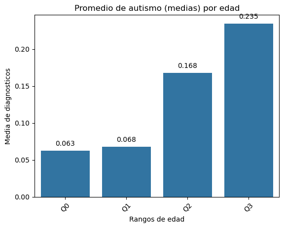

```python
# Creamos un diccionario con las etiquetas de
# 'age_group_encoded':
age_group_map = {
    0 : "Q0",
    1 : "Q1",
    2 : "Q2",
    3 : "Q3"
}

# Mapeamos los índices (códigos) de la serie a los
# cuartiles creados
age_count_labels = percentage_autism_by_age.index.map(age_group_map)

# Gráfico de barras del promedio de autismo por
# edad agrupada
ax = sns.barplot(x=age_count_labels, y=age_group_promedy.values)
plt.xlabel('Rangos de edad')
plt.ylabel('Media de diagnosticos')
plt.title('Promedio de autismo (medias) por edad')
plt.xticks(rotation=45)

# Agregamos etiquetas con los valores encima de las barras
for p in ax.patches:
    ax.annotate(f'{p.get_height():.3f}',
                (p.get_x() + p.get_width() / 2., p.get_height()),
                ha = 'center', va = 'center',
                xytext = (0, 10),
                textcoords = 'offset points')
plt.show
```

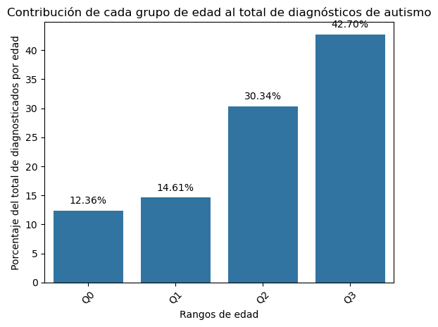

```python
# Gráfico de barras del porcentaje de autismo por age_group_encoded del total
ax = sns.barplot(x=age_count_labels,
                 y=percentage_autism_by_age_total.values)
plt.xlabel('Rangos de edad')
plt.ylabel('Porcentaje del total de diagnosticados por edad')
plt.title('Contribución de cada grupo de edad al total de diagnósticos de autismo')
plt.xticks(rotation=45)

# Agregamos etiquetas con los valores encima de las barras
for p in ax.patches:
    ax.annotate(f'{p.get_height():.2f}%',
                (p.get_x() + p.get_width() / 2., p.get_height()),
                ha = 'center', va = 'center',
                xytext = (0, 10),
                textcoords = 'offset points')

plt.show()
```

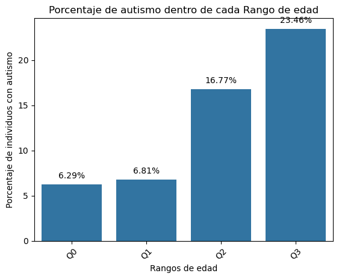

```python
# Gráfico de barras del porcentaje de autismo por edad agrupada
ax = sns.barplot(x=age_count_labels,
                 y=percentage_autism_by_age.values)
plt.xlabel('Rangos de edad')
plt.ylabel('Porcentaje de individuos con autismo')
plt.title('Porcentaje de autismo dentro de cada Rango de edad')
plt.xticks(rotation=45)

# Agregamos etiquetas con los valores encima de las barras
for p in ax.patches:
    ax.annotate(f'{p.get_height():.2f}%',
                (p.get_x() + p.get_width() / 2., p.get_height()),
                ha = 'center', va = 'center',
                xytext = (0, 10),
                textcoords = 'offset points')

plt.show()
```

4. ロジスティック回帰分析:

***AGE_GROUP_ENCODED***

```python
import statsmodels.api as sm
from sklearn.linear_model import LogisticRegression

# Creamos un modelo de regresión logística con
# 'age_group_encoded' como predictor
model_log_reg = LogisticRegression()
model_log_reg .fit(df[['age_group_encoded']], df['austim'])

# Usamos statsmodels para obtener los valores p
# Agregamos una constante para el término de intersección
X = sm.add_constant(df[['age_group_encoded']])
logit_model = sm.Logit(df['austim'], X)
result = logit_model.fit()
p_values = result.pvalues

# Obtenemos los coeficientes y el valor p de la etnia
age_coef = model_log_reg.coef_[0][0]
age_p_value = p_values['age_group_encoded']

print(f"Coeficiente de la edad discretizada:\
      {age_coef}, Valor p: {age_p_value}")

# Otras estadisticas relevantes:
print("Pseudo R-cuadrado:", result.prsquared)
print("Log-likelihood:", result.llf)
print("AIC:", result.aic)
print("BIC:", result.bic)
```

```
Optimization terminated successfully.
         Current function value: 0.363726
         Iterations 7
Coeficiente de la edad discretizada:      0.5688916667795982, Valor p: 2.707410875924761e-07
Pseudo R-cuadrado: 0.05479230756061271
Log-likelihood: -250.60745788755546
AIC: 505.2149157751109
BIC: 514.2853983171382
```

```python
# convertimos la notacion cientifica a decimal
num_decimal: float = float(p_value)
print(f"Valor p: {num_decimal:.20f}")
```

```
Valor p: 0.00000073320297342641
```

***分析結果のロジスティック回帰モデルによる年齢の離散化*** 年齢を四分位点に離散化して自閉症スペクトラム障害（ASD）の診断の予測因子として使用したロジスティック回帰分析は、両変数間で統計的に有意義な関連性を明らかにしました。

p値は、従来の有意水準0.05よりも著しく低いため、年齢が、離散化された形式であっても、このサンプルにおける自閉症の関連する予測因子であるという結論を支持しています。

その他の統計量：

- **擬似R二乗**: 0.0548 この指標は、McFaddenのR二乗とも呼ばれ、ロジスティック回帰モデルの適合度を測定します。0から1の範囲で、値が高いほど適合度が高いことを示します。この場合、0.055の値は、モデルが自閉症の診断の分散のわずかな部分しか説明していないことを示しています。
- **対数尤度**: -250.607 これは、適合されたモデルの尤度関数の対数です。観測データにどれだけよくフィットしているかを測定する指標です。値が高いほどフィットが良いことを示します。
- **AIC: 505.215, BIC: 514.285** AIC（赤池情報量基準）とBIC（ベイズ情報量基準）は、モデルの選択に使用される指標です。パラメータが多いモデルをペナルティとして過剰適合を防ぐため、AICとBICの値が低いほどモデルのフィットが良いことを示します。

解釈と考慮事項：

これらの結果は、このサンプルにおいて、年齢の高いグループの個人が、若い個人に比べてASDの診断を受ける可能性が高いことを示唆しています。この観察は、以下のような要因に関連している可能性があります：

- **成人での診断の難しさ**: 自閉症は成人において異なる形で現れることがあり、子供に比べて識別および診断が難しいため、遅れて診断される可能性があります。
- **サンプルの偏り**: サンプルが自閉症を持つ年上の個人に偏っている可能性もあります。

## データセットの説明

ETLプロセスから得られたデータセットには、自閉症スペクトラム障害（ASD）のスクリーニング研究に参加した689人の成人に関する情報が含まれています。各レコードには以下の特徴が含まれます:

1. **AQ-10テストスコア** *(a(x)_score)*: 自閉症特性を評価するための二択（はい/いいえ）の10の質問。値は0-1。***項目 `a2_score` および `a7_score` は削除されました***
2. **年齢** *(age)*: 参加者の年齢（年単位）。
3. **性別** *(gender)*: 0（女性）、1（男性）としてコード化。***最終版の教師ありモデルでは削除されました***
4. **出生時の黄疸** *(jundex)*: 0（いいえ）、1（はい）としてコード化。***最終版の教師ありモデルでは削除されました***
5. **自閉症の診断** *(austim)*: 0（いいえ）、1（はい）としてコード化。
6. **AQ-10の合計スコア** *(result)*: 10の質問のスコアの合計。範囲は0-10。
7. **AQ-10結果のバイナリ結果** *(aq_binary)*: $$result{>= 6}$$ の診断に対するバイナリ値。
8. **民族** *(eth_cat)*: 参加者の民族カテゴリを数値でコード化。

このデータセットは、欠損値や不整合を除去し、カテゴリ変数を機械学習モデルで使用可能な形式にエンコードするためにクリーンアップおよび前処理されました。

### ETLセクションの締めくくり

ETLプロセスの完了により、元のデータセット ***"Autism Screening Adult"*** を分析およびモデリングに適した形式に変換することができました。欠損値や不整合なカテゴリなどのデータ品質の問題は解決され、カテゴリ変数も機械学習アルゴリズムで使用できるようにコード化されました。

結果として得られたデータセットは、成人におけるASDリスクを予測するための次のプロジェクト段階の基盤を提供します。このデータセットが、自閉症に影響を与える要因の理解を深め、早期発見のためのより正確なツールの開発に貢献することを期待しています。

```python
# Eliminamos los datos de cluster OPTICS
df.drop(columns=['cluster_optics'], inplace=True)
# copia de seguridad del conjunto de datos en este punto:
df.to_csv("autism_adult_etl.csv", index=False)
# Visualizamos la estructura del df
df.describe()
```

|  | a1_score | a3_score | a4_score | a5_score | a6_score | a8_score | a9_score | a10_score | age | austim | result | eth_cat | aq_binary | relation_coded | age_group_encoded | k-means |
| --- | --- | --- | --- | --- | --- | --- | --- | --- | --- | --- | --- | --- | --- | --- | --- | --- |
| count | 689.000000 | 689.000000 | 689.000000 | 689.000000 | 689.000000 | 689.000000 | 689.000000 | 689.000000 | 689.000000 | 689.000000 | 689.000000 | 689.000000 | 689.000000 | 689.000000 | 689.000000 | 689.000000 |
| mean | 0.725689 | 0.455733 | 0.496372 | 0.499274 | 0.280116 | 0.654572 | 0.322206 | 0.577649 | 29.239478 | 0.129173 | 4.885341 | 3.253991 | 0.368650 | 1.673440 | 1.449927 | 0.328012 |
| std | 0.446490 | 0.498398 | 0.500350 | 0.500363 | 0.449382 | 0.475853 | 0.467661 | 0.494293 | 9.745116 | 0.335635 | 2.495328 | 2.311043 | 0.482789 | 0.602229 | 1.107928 | 0.469830 |
| min | 0.000000 | 0.000000 | 0.000000 | 0.000000 | 0.000000 | 0.000000 | 0.000000 | 0.000000 | 17.000000 | 0.000000 | 0.000000 | 1.000000 | 0.000000 | 0.000000 | 0.000000 | 0.000000 |
| 25% | 0.000000 | 0.000000 | 0.000000 | 0.000000 | 0.000000 | 0.000000 | 0.000000 | 0.000000 | 21.000000 | 0.000000 | 3.000000 | 1.000000 | 0.000000 | 1.000000 | 0.000000 | 0.000000 |
| 50% | 1.000000 | 0.000000 | 0.000000 | 0.000000 | 0.000000 | 1.000000 | 0.000000 | 1.000000 | 27.000000 | 0.000000 | 4.000000 | 2.000000 | 0.000000 | 2.000000 | 1.000000 | 0.000000 |
| 75% | 1.000000 | 1.000000 | 1.000000 | 1.000000 | 1.000000 | 1.000000 | 1.000000 | 1.000000 | 35.000000 | 0.000000 | 7.000000 | 5.000000 | 1.000000 | 2.000000 | 2.000000 | 1.000000 |
| max | 1.000000 | 1.000000 | 1.000000 | 1.000000 | 1.000000 | 1.000000 | 1.000000 | 1.000000 | 64.000000 | 1.000000 | 10.000000 | 7.000000 | 1.000000 | 2.000000 | 3.000000 | 1.000000 |

### **ロジスティック回帰モデル - 二値分類 (I)**

このセクションでは、成人における自閉症スペクトラム障害（ASD）の診断を予測する二値分類モデルを構築します。 ターゲット変数として、すでに0（非自閉症）と1（自閉症）にコード化された`austim`を使用します。

目標は、AQ-10アンケートの回答、年齢、民族など、データセットに含まれる特徴から、これらの2つのクラスを区別する機械学習アルゴリズムを訓練することです。

二値分類の適切な指標を使用してモデル性能を評価します。例えば、精度、再現率、F1スコア、およびROC曲線下の面積（AUC-ROC）など。これらの指標により、モデルがASDの有無を正確に識別し、両方のクラスを区別する能力を判断できます。

このモデルを通じて、ASDのリスクが高い人を特定し、早期診断と治療へのアクセスを促進するツールを開発したいと考えています。

**考慮事項:**

- **特徴選択:** ASDを予測するために最も関連する特徴を決定するために、さまざまな特徴の組み合わせを探索します。
- **分類アルゴリズム:** ロジスティック回帰、決定木、サポートベクターマシンなどのさまざまな分類アルゴリズムを試行し、データに最も適したものを特定します。
- **ハイパーパラメータの最適化:** モデルのパフォーマンスを最大化するために、ハイパーパラメータを調整します。
- **解釈性:** 正確なだけでなく、解釈可能なモデルを探し、ASDを予測する上で最も重要な要因を理解します。

**評価指標:**

- **精度:** 全予測のうち正しい予測の割合。
- **再現率（感度）:** 自閉症（陽性）を正確に識別した割合。
- **F1スコア:** 精度と再現率の調和平均であり、両方の指標をバランスさせます。
- **AUC-ROC:** ROC曲線下の面積であり、モデルが陽性と陰性のクラスを区別する能力を測定します。

**目的:**

- 成人におけるASD診断を予測するための正確でロバストな二値分類モデルを開発する。
- ASD予測の最も関連する特徴を特定する。
- 適切な指標を使用してモデルの性能を評価する。
- ASDリスクに影響を与える要因の理解に貢献する。

```python
# Dividimos el dataset en variables dependientes e independientes
# Variables independientes
X = df.drop(columns=['austim'])
# Variable dependiente
y = df['austim']
```

We are going to create stratified splits for training and testing, since as we have elucidated previously, there is a class imbalance.

```python
from sklearn.model_selection import train_test_split

X_train, X_test, y_train, y_test = \
    train_test_split(X, y, test_size=0.2, stratify=y, random_state=42)
# test_size=0.2 indica que el 20% de los datos se utilizarán para pruebas
# stratify=y garantiza que las proporciones de las clases en y se mantengan
# random_state=42 asegura que los resultados sean reproducibles
```

#### ディープニューラルネットワーク（DNN）またはマルチライヤーパーセプトロン（MLP）モデル

連続して一つ一つ積み重ねられたレイヤーから構成される人工神経ネットワーク。この特定の場合、複数の密なレイヤー（完全に接続された）を持つ *Keras* の `sequential` モデルを使用します。

DNN モデルを作成するために、SMOTE サンプルのフィットと One-Hot Encoding の適用を使用します。

```python
import pandas as pd
import tensorflow as tf
from tensorflow import keras
from tensorflow.keras import layers, models
from tensorflow.keras.optimizers import Adam, RMSprop
from tensorflow.keras.regularizers import l1, l2, l1_l2
from sklearn.model_selection import train_test_split
from sklearn.metrics import accuracy_score, precision_score, recall_score, f1_score, roc_auc_score
from imblearn.over_sampling import SMOTE
import numpy as np
import keras_tuner as kt

# Cargamos el DataFrame
df = pd.read_csv("autism_adult_etl.csv")

# Separamos características (X) y etiquetas (y)
X = df.drop(columns=['austim'])
y = df['austim']

# Dividimos en entrenamiento y prueba
X_train, X_test, y_train, y_test = train_test_split(X, y, test_size=0.2, stratify=y, random_state=42)

# Aplicamos One-Hot Encoding a las variables categóricas seleccionadas
X_train = pd.get_dummies(X_train, columns=['eth_cat', 'age_group_encoded', 'relation_coded'])
X_test = pd.get_dummies(X_test, columns=['eth_cat', 'age_group_encoded', 'relation_coded'])

# Aseguramos que ambas matrices tengan las mismas columnas después de One-Hot Encoding
X_train, X_test = X_train.align(X_test, join='left', axis=1, fill_value=0)

# Convertimo las columnas bool a enteros (int)
X_train = X_train.astype({col: 'int32' for col in X_train.select_dtypes('bool').columns})
X_test = X_test.astype({col: 'int32' for col in X_test.select_dtypes('bool').columns})

# Convertimos a float32 para TensorFlow
X_train = X_train.astype('float32')
X_test = X_test.astype('float32')

# Aplicamos remuestreo SMOTE
smote = SMOTE(random_state=42)
X_train_resampled, y_train_resampled = smote.fit_resample(X_train, y_train)

# Construimos un modelo de busqueda de hiperparametros:
def build_model(hp):
    model = models.Sequential()
    model.add(layers.Input(shape=(X_train_resampled.shape[1],)))

    # Opciones sobre número de capas ocultas
    for i in range(hp.Int('num_hidden_layers', 1, 3)):
        # Elegir regularizador
        reg_choice = hp.Choice(f'regularizer_{i}', ['none', 'l1', 'l2', 'l1_l2'])
        if reg_choice == 'none':
            regularizer = None
        elif reg_choice == 'l1':
            regularizer = l1(hp.Float(f'l1_{i}', 1e-6, 1e-2, sampling='log'))
        elif reg_choice == 'l2':
            regularizer = l2(hp.Float(f'l2_{i}', 1e-6, 1e-2, sampling='log'))
        else:  # l1_l2
            regularizer = l1_l2(
                l1=hp.Float(f'l1_{i}', 1e-6, 1e-2, sampling='log'),
                l2=hp.Float(f'l2_{i}', 1e-6, 1e-2, sampling='log')
            )

        model.add(layers.Dense(units=hp.Int(f'units_{i}', min_value=16, max_value=128, step=16),
                               activation='tanh',
                               kernel_regularizer=regularizer))
        model.add(layers.Dropout(hp.Float(f'dropout_{i}', 0, 0.5, step=0.1)))

    model.add(layers.Dense(1, activation='sigmoid'))

    # Opciones sobre optimizador
    optimizer_choice = hp.Choice('optimizer', values=['adam', 'rmsprop'])
    if optimizer_choice == 'adam':
        optimizer = Adam(hp.Float('learning_rate', 1e-4, 1e-2, sampling='log'))
    else:
        optimizer = RMSprop(hp.Float('learning_rate', 1e-4, 1e-2, sampling='log'))

    model.compile(optimizer=optimizer,
                  loss='binary_crossentropy',
                  metrics=['accuracy'])
    return model

# Creamos un objeto tuner
tuner = kt.Hyperband(build_model,
                     objective='val_accuracy',
                     max_epochs=100,
                     factor=3,
                     directory='keras_tuner',
                     project_name='autism_classification')

# Realizamos la búsqueda de hiperparámetros
tuner.search(X_train_resampled, y_train_resampled,
             epochs=50,
             validation_split=0.2,
             callbacks=[tf.keras.callbacks.EarlyStopping('val_loss', patience=5)])

# Obtenemos el mejor modelo
best_hps = tuner.get_best_hyperparameters(num_trials=1)[0]
best_model = tuner.hypermodel.build(best_hps)

# Entrenamos el mejor modelo
history = best_model.fit(X_train_resampled, y_train_resampled,
                         epochs=100,
                         validation_split=0.2,
                         callbacks=[tf.keras.callbacks.EarlyStopping('val_loss', patience=10)])

# Evaluamos el mejor modelo en el conjunto de prueba
y_pred_prob = best_model.predict(X_test)
y_pred = (y_pred_prob > 0.5).astype(int)

# Calculamos métricas de evaluación
accuracy = accuracy_score(y_test, y_pred)
precision = precision_score(y_test, y_pred)
recall = recall_score(y_test, y_pred)
f1 = f1_score(y_test, y_pred)
auc_roc = roc_auc_score(y_test, y_pred_prob)
```

```python
# Imprimimos las métricas de evaluación
print(f"Accuracy: {accuracy}")
print(f"Precision: {precision}")
print(f"Recall: {recall}")
print(f"F1 Score: {f1}")
print(f"AUC-ROC: {auc_roc}")

# Imprimimos los mejores hiperparámetros
print("Mejores hiperparámetros encontrados:")
print(best_hps.values)
```

```
Accuracy: 0.7463768115942029
Precision: 0.22580645161290322
Recall: 0.3888888888888889
F1 Score: 0.2857142857142857
AUC-ROC: 0.6972222222222222
Mejores hiperparámetros encontrados:
{'num_hidden_layers': 2, 'regularizer_0': 'l1', 'units_0': 64, 'dropout_0': 0.1, 'optimizer': 'rmsprop', 'learning_rate': 0.004299211781488068, 'l1_0': 2.1873541296444933e-06, 'regularizer_1': 'l1', 'units_1': 32, 'dropout_1': 0.0, 'l2_1': 8.110681285395487e-05, 'regularizer_2': 'none', 'units_2': 6…
```

**SMOTEとOne-Hot Encodingを用いたニューラルネットワークモデルの分析と結論**

SMOTEオーバーサンプリング技術とOne-Hot Encodingをカテゴリ変数に適用したニューラルネットワークモデルは、成人における自閉スペクトラム症（ASD）の二値分類タスクにおいて中程度の性能を示しました。Keras Tunerを用いたハイパーパラメータ最適化の努力にもかかわらず、評価指標はモデルの予測能力にある程度の限界があることを明らかにしています。

解釈と限界

得られた結果は、リサンプリング技術とハイパーパラメータ最適化を適用したにもかかわらず、ニューラルネットワークモデルがASDの個人を正しく識別するのに苦労していることを示しています。特に、多数派クラス（非ASD）と比較した場合に顕著です。これは、障害の inherent complexity、データセットに十分な情報を含む特徴がない可能性、またはモデルのアーキテクチャと設定の限界などが原因である可能性があります。

リサンプリング後でもクラス不均衡が依然として大きな課題であることを強調することが重要です。モデルは多数派クラスの予測を優先する傾向があり、その結果、高い偽陽性率と低い再現率につながっています。

#### Modelo XGBoost

```python
import xgboost as xgb
from sklearn.metrics import accuracy_score, precision_score, recall_score, f1_score, roc_auc_score
from sklearn.model_selection import train_test_split
from sklearn.preprocessing import StandardScaler
from imblearn.combine import SMOTETomek
import pandas as pd
import numpy as np

# Separamos características (X) y etiquetas (y)
X = df.drop(columns=['austim'])
y = df['austim']

# Dividimos en entrenamiento y prueba
X_train, X_test, y_train, y_test = train_test_split(X, y, test_size=0.2, stratify=y, random_state=42)

# Aplicamos One-Hot Encoding a las variables categóricas seleccionadas
X_train = pd.get_dummies(X_train, columns=['eth_cat', 'age_group_encoded', 'relation_coded'])
X_test = pd.get_dummies(X_test, columns=['eth_cat', 'age_group_encoded', 'relation_coded'])

# Aseguramos que ambas matrices tengan las mismas columnas después de One-Hot Encoding
X_train, X_test = X_train.align(X_test, join='outer', axis=1, fill_value=0)

# Aplicar escalado
scaler = StandardScaler()
X_train_scaled = scaler.fit_transform(X_train)
X_test_scaled = scaler.transform(X_test)

# Aplicar SMOTE-Tomek (una alternativa a SMOTE-ENN que suele ser más rápida y efectiva)
smote_tomek = SMOTETomek(random_state=42)
X_train_resampled, y_train_resampled = smote_tomek.fit_resample(X_train_scaled, y_train)

# Crear el modelo XGBoost
xgb_model = xgb.XGBClassifier(
    objective='binary:logistic',
    eval_metric='logloss',
    scale_pos_weight=(len(y_train[y_train == 0]) / len(y_train[y_train == 1])),
    random_state=42,
    n_estimators=100,
    learning_rate=0.1,
    max_depth=3
)

# Entrenamos el modelo
xgb_model.fit(X_train_resampled, y_train_resampled)

# Predecimos sobre conjunto de prueba
y_pred_prob = xgb_model.predict_proba(X_test_scaled)[:, 1]
y_pred = (y_pred_prob > 0.5).astype(int)

# Evaluamos el modelo
accuracy = accuracy_score(y_test, y_pred)
precision = precision_score(y_test, y_pred)
recall = recall_score(y_test, y_pred)
f1 = f1_score(y_test, y_pred)
auc_roc = roc_auc_score(y_test, y_pred_prob)

print("\nModelo: XGBoost")
print("Accuracy:", accuracy)
print("Precision:", precision)
print("Recall:", recall)
print("F1-score:", f1)
print("AUC-ROC:", auc_roc)

# Imprimimos las características más importantes
feature_importance = xgb_model.feature_importances_
feature_names = X_train.columns
sorted_idx = np.argsort(feature_importance)
for idx in sorted_idx[-10:]:
    print(f"{feature_names[idx]}: {feature_importance[idx]:.4f}")
```

```
Modelo: XGBoost
Accuracy: 0.717391304347826
Precision: 0.23076923076923078
Recall: 0.5
F1-score: 0.3157894736842105
AUC-ROC: 0.6712962962962964
a8_score: 0.0271
a10_score: 0.0326
relation_coded_2: 0.0367
a9_score: 0.0426
a1_score: 0.0690
a4_score: 0.0815
age_group_encoded_0: 0.0838
eth_cat_2: 0.0877
aq_binary: 0.0993
eth_cat_1: 0.1971
```

**XGBoostモデルの評価**

One-Hot Encodingを使用して特徴量をエンコードし、リサンプリングされたデータセットで学習されたXGBoostモデルは、成人における自閉スペクトラム症（ASD）の検出という二値分類タスクにおいて許容できる性能を示しました。得られた精度は71.74%であり、これはモデルがテストセットの約4分の3のインスタンスを正しく分類していることを示しています。ただし、この指標は元のデータに存在するクラス不均衡の影響を受けやすいことに注意することが重要です。

パフォーマンス指標を詳しく見てみると、再現率（感度）は50%であり、これは肯定的な結果です。これは、モデルがテストセット内の実際のASD症例の半分を識別できることを示しています。しかし、適合率は23.08%であり、かなりの偽陽性率があることを示唆しています。つまり、モデルは実際にASDを持っていないかなりの割合の個人に対してASDの存在を予測する傾向があります。

適合率と再現率を一つの指標にまとめたF1スコアの値は0.316です。この値は、両方の指標の間で中程度のバランスが取れていることを反映しており、モデルがいずれかの指標で際立っているわけではないが、どちらにおいても極端に低いパフォーマンスを示していないことを示しています。ROC曲線下面積（AUC-ROC）は0.671であり、許容できる識別能力を示していますが、改善の余地があります。

結論 XGBoostモデルは、全体的な精度は許容できるものの、特に陽性精度に関しては、ASDの有無を持つ個人を区別する能力に限界があります。クラス不均衡は、リサンプリングを行ったにもかかわらず、依然としてモデルの性能に影響を与える可能性があります。

#### LightGBM Model

```python
# Modelo LightGBM
import lightgbm as lgb
from sklearn.metrics import accuracy_score, precision_score, recall_score, f1_score, roc_auc_score
from sklearn.model_selection import train_test_split
from sklearn.preprocessing import StandardScaler
from imblearn.combine import SMOTETomek
import pandas as pd
import numpy as np

# Separamos características (X) y etiquetas (y)
X = df.drop(columns=['austim'])
y = df['austim']

# Dividimos en entrenamiento y prueba
X_train, X_test, y_train, y_test = train_test_split(X, y, test_size=0.2, stratify=y, random_state=42)

# Aplicamos One-Hot Encoding a las variables categóricas seleccionadas
X_train = pd.get_dummies(X_train, columns=['eth_cat', 'age_group_encoded', 'relation_coded'])
X_test = pd.get_dummies(X_test, columns=['eth_cat', 'age_group_encoded', 'relation_coded'])

# Aseguramos que ambas matrices tengan las mismas columnas después de One-Hot Encoding
X_train, X_test = X_train.align(X_test, join='outer', axis=1, fill_value=0)

# Aplicar escalado
scaler = StandardScaler()
X_train_scaled = scaler.fit_transform(X_train)
X_test_scaled = scaler.transform(X_test)

# Aplicamos SMOTE-Tomek
smote_tomek = SMOTETomek(random_state=42)
X_train_resampled, y_train_resampled = smote_tomek.fit_resample(X_train_scaled, y_train)

# Creamos el modelo LightGBM
lgb_model = lgb.LGBMClassifier(
    objective='binary',
    metric='binary_logloss',
    is_unbalance=True,
    random_state=42,
    n_estimators=100,
    learning_rate=0.1,
    num_leaves=31,
    max_depth=-1  # -1 = sin límite de profundidad
)

# Entrenamos el modelo
lgb_model.fit(X_train_resampled, y_train_resampled)

# Predecimos sobre conjunto de prueba
y_pred_prob = lgb_model.predict_proba(X_test_scaled)[:, 1]
y_pred = (y_pred_prob > 0.5).astype(int)

# Evaluamos el modelo
accuracy = accuracy_score(y_test, y_pred)
precision = precision_score(y_test, y_pred)
recall = recall_score(y_test, y_pred)
f1 = f1_score(y_test, y_pred)
auc_roc = roc_auc_score(y_test, y_pred_prob)

print("\nModelo: LightGBM")
print("Accuracy:", accuracy)
print("Precision:", precision)
print("Recall:", recall)
print("F1-score:", f1)
print("AUC-ROC:", auc_roc)

# mos las características más importantes
feature_importance = lgb_model.feature_importances_
feature_names = X_train.columns
sorted_idx = np.argsort(feature_importance)
print("\nCaracterísticas más importantes:")
for idx in sorted_idx[-10:]:
    print(f"{feature_names[idx]}: {feature_importance[idx]:.4f}")
```

```
[LightGBM] [Info] Number of positive: 477, number of negative: 477
[LightGBM] [Info] Auto-choosing row-wise multi-threading, the overhead of testing was 0.004658 seconds.
You can set `force_row_wise=true` to remove the overhead.
And if memory is not enough, you can set `force_col_wise=true`.
[LightGBM] [Info] Total Bins 813
[LightGBM] [Info] Number of data points in the train set: 954, number of used features: 26
[LightGBM] [Info] [binary:BoostFromScore]: pavg=0.500000 -> initscore=0.000000

Modelo: LightGBM
Accuracy: 0.8333333333333334
Precision: 0.3076923076923077
Recall: 0.2222222222222222
F1-score: 0.25806451612903225
AUC-ROC: 0.6986111111111111

Características más importantes:
relation_coded_2: 98.0000
a5_score: 104.0000
a4_score: 104.0000
a6_score: 120.0000
eth_cat_1: 124.0000
a3_score: 140.0000
a8_score: 141.0000
a10_score: 149.0000
result: 488.0000
age: 982.0000
```

**結果の解釈**  
SMOTE-TomekによるリサンプリングとOne-Hot Encodingによる特徴量エンコーディングを用いて学習したLightGBMモデルは、成人における自閉スペクトラム症（ASD）の検出という二値分類タスクにおいて、まずまずの性能を示しました。得られた精度は83.33%であり、これは、モデルがテストセットのほとんどのインスタンスを正しく分類していることを示しています。しかし、この指標は元のデータに存在するクラス不均衡の影響を受ける可能性があることに注意することが重要です。

適合率と再現率を一つの指標にまとめたF1スコアの値は0.258です。この値は、特に陽性症例の検出において、モデルの全体的なパフォーマンスが低いことを反映しています。ROC曲線下面積（AUC-ROC）は0.699であり、中程度の識別能力を示していますが、改善の余地があります。

特徴量の重要度分析 特徴量の重要度分析から、年齢がモデルの予測に最も貢献している変数であり、次にresult（AQ-10の合計スコア）とa10_scoreが続くことが明らかになりました。これは、年齢とAQ-10テストの質問10への回答が、このサンプルにおけるASDの識別において関連性の高い要因であることを示唆しています。a8_score、a3_score、eth_cat_1（白人の民族性）、a6_scoreなどの他の特徴量も、ある程度の重要性を示していますが、その程度は低いものです。

#### ロジスティック回帰モデル

```python
# Modelo de regresión logística múltiple
import statsmodels.api as sm
from sklearn.linear_model import LogisticRegression
from sklearn.model_selection import train_test_split
from sklearn.metrics import accuracy_score, precision_score, recall_score, f1_score, roc_auc_score

# Separamos características (X) y etiquetas (y)
X = df.drop(columns=['austim'])
y = df['austim']

# Dividimos en entrenamiento y prueba
X_train, X_test, y_train, y_test = train_test_split(X, y, test_size=0.2, stratify=y, random_state=42)

# Aplicamos One-Hot Encoding a las variables categóricas seleccionadas
X_train = pd.get_dummies(X_train, columns=['eth_cat', 'age_group_encoded', 'relation_coded'])
X_test = pd.get_dummies(X_test, columns=['eth_cat', 'age_group_encoded', 'relation_coded'])

# Aseguramos que ambas matrices tengan las mismas columnas después de One-Hot Encoding
X_train, X_test = X_train.align(X_test, join='outer', axis=1, fill_value=0)

# Aplicamos escalado
scaler = StandardScaler()
X_train_scaled = scaler.fit_transform(X_train)
X_test_scaled = scaler.transform(X_test)

# Aplicamos SMOTE-Tomek
smote_tomek = SMOTETomek(random_state=42)
X_train_resampled, y_train_resampled = smote_tomek.fit_resample(X_train_scaled, y_train)

# Creamos y entrenar el modelo de regresión logística múltiple
model = LogisticRegression(max_iter=1000)
model.fit(X_train_resampled, y_train_resampled)

# Predecimos con base en el conjunto de prueba
y_pred_prob = model.predict_proba(X_test_scaled)
y_pred_prob = y_pred_prob[:, 1]
y_pred = (y_pred_prob > 0.5).astype(int)

# Evaluamos el modelo
accuracy = accuracy_score(y_test, y_pred)
precision = precision_score(y_test, y_pred)
recall = recall_score(y_test, y_pred)
f1 = f1_score(y_test, y_pred)
auc_roc = roc_auc_score(y_test, y_pred_prob)

# Imprimimos las métricas de evaluación
print("\nModelo: Regresión Logística Múltiple")
print("Accuracy:", accuracy)
print("Precision:", precision)
print("Recall:", recall)
print("F1-score:", f1)
print("AUC-ROC:", auc_roc)

# Usamos statsmodels para obtener los valores p y la tabla de coeficientes
# Agregar una constante para el término de intersección
X_with_const = sm.add_constant(X_train_resampled)
logit_model = sm.Logit(y_train_resampled, X_with_const)
result = logit_model.fit()

# Imprimimos la tabla de coeficientes con intervalos de confianza
print(result.summary())
```

```
Modelo: Regresión Logística Múltiple
Accuracy: 0.7318840579710145
Precision: 0.24324324324324326
Recall: 0.5
F1-score: 0.32727272727272727
AUC-ROC: 0.7023148148148148
Optimization terminated successfully.
         Current function value: 0.483363
         Iterations 17
                           Logit Regression Results
==============================================================================
Dep. Variable:                 austim   No. Observations:                  954
Model:                          Logit   Df Residuals:                      930
Method:                           MLE   Df Model:                           23
Date:                Mon, 09 Sep 2024   Pseudo R-squ.:                  0.3027
Time:                        16:15:15   Log-Likelihood:                -461.13
converged:                       True   LL-Null:                       -661.26
Covariance Type:            nonrobust   LLR p-value:                 1.565e-70
==============================================================================
                 coef    std err          z      P>|z|      [0.025      0.975]
------------------------------------------------------------------------------
const         -0.8946      0.107     -8.380      0.000      -1.104      -0.685
x1             0.4699      0.131      3.585      0.000       0.213       0.727
x2             0.3830      0.132      2.902      0.004       0.124       0.642
x3             0.4141      0.133      3.105      0.002       0.153       0.675
x4             0.0351      0.139      0.252      0.801      -0.238       0.308
x5             0.1079      0.130      0.833      0.405      -0.146       0.362
x6            -0.0320      0.123     -0.259      0.795      -0.274       0.210
x7             0.5065      0.148      3.417      0.001       0.216       0.797
x8             0.1939      0.127      1.524      0.127      -0.055       0.443
x9            -0.4586      0.226     -2.033      0.042      -0.901      -0.017
x10            0.0667      0.381      0.175      0.861      -0.681       0.814
x11           -0.0060      0.193     -0.031      0.975      -0.384       0.372
x12           -0.5926      0.207     -2.869      0.004      -0.997      -0.188
x13            0.4377        nan        nan        nan         nan         nan
x14           -0.4675        nan        nan        nan         nan         nan
x15            0.0515        nan        nan        nan         nan         nan
x16            0.0142        nan        nan        nan         nan         nan
x17           -0.0505        nan        nan        nan         nan         nan
x18            0.2450        nan        nan        nan         nan         nan
x19           -0.2127        nan        nan        nan         nan         nan
x20           -0.7462   3.03e+06  -2.46e-07      1.000   -5.94e+06    5.94e+06
x21           -0.2444   3.18e+06  -7.68e-08      1.000   -6.23e+06    6.23e+06
x22            0.4548   3.09e+06   1.47e-07      1.000   -6.06e+06    6.06e+06
x23            0.5475   2.98e+06   1.84e-07      1.000   -5.85e+06    5.85e+06
x24            0.0950   2.91e+06   3.27e-08      1.000   -5.69e+06    5.69e+06
x25            0.0991   4.47e+06   2.21e-08      1.000   -8.77e+06    8.77e+06
x26           -0.1434   5.02e+06  -2.86e-08      1.000   -9.83e+06    9.83e+06
==============================================================================
```

***Evaluation of the Multiple Logistic Regression Model***

The multiple logistic regression model, trained on the resampled dataset and with features encoded using One-Hot Encoding, exhibits moderate performance on the binary classification task of Autism Spectrum Disorder (ASD) in adults. The accuracy obtained was 73.19%, indicating that the model correctly classifies about three-quarters of the instances in the test set. However, this metric can be misleading in the presence of class imbalance, as is the case in this dataset.

A closer look at the performance metrics reveals a recall (sensitivity) of 50%, meaning that the model is able to identify half of the real cases of ASD in the test set. The precision of the model was 24.32%, indicating a considerable rate of false positives. That is, the model tends to predict the presence of ASD in a significant proportion of individuals who do not actually have it.

The F1-score value, which combines precision and recall in a single metric, is 0.327. This value reflects a moderate balance between both metrics. The area under the ROC curve (AUC-ROC) of 0.702 suggests an acceptable discriminatory capacity, but with room for improvement.

***Analysis of the statistical significance of the predictors***

***Conclusions***

The multiple logistic regression model, although showing a moderate overall performance, demonstrates the ability to identify some relevant predictor variables for the diagnosis of ASD. However, the model still shows limitations in its ability to discriminate between individuals with and without ASD, especially in terms of positive accuracy.

**多重ロジスティック回帰モデルの評価**  
One-Hot Encodingを使用して特徴量をエンコードし、リサンプリングされたデータセットで学習された多重ロジスティック回帰モデルは、成人における自閉スペクトラム症（ASD）の二値分類タスクにおいて中程度の性能を示しました。得られた精度は73.19%であり、これはモデルがテストセットの約4分の3のインスタンスを正しく分類していることを示しています。しかし、このデータセットのようにクラス不均衡が存在する場合、この指標は誤解を招く可能性があります。

パフォーマンス指標を詳しく見てみると、再現率（感度）は50%であり、これはモデルがテストセット内の実際のASD症例の半分を識別できることを意味します。モデルの適合率は24.32%であり、かなりの偽陽性率があることを示しています。つまり、モデルは実際にASDを持っていないかなりの割合の個人に対してASDの存在を予測する傾向があります。

適合率と再現率を一つの指標にまとめたF1スコアの値は0.327です。この値は、両方の指標の間で中程度のバランスが取れていることを反映しています。ROC曲線下面積（AUC-ROC）は0.702であり、許容できる識別能力を示していますが、改善の余地があります。

**結論**  
多重ロジスティック回帰モデルは、全体的なパフォーマンスは中程度ですが、ASDの診断に関連するいくつかの予測変数を特定する能力を示しています。しかし、モデルは依然としてASDの有無を持つ個人を区別する能力に限界があり、特に陽性精度に関しては改善の余地があります。

### 多クラス分類モデル

```python
# Revisamos las variables de nuestro dataset
df = pd.read_csv("autism_adult_etl.csv")
df.info()
```

```
<class 'pandas.core.frame.DataFrame'>
RangeIndex: 689 entries, 0 to 688
Data columns (total 16 columns):
 #   Column             Non-Null Count  Dtype
---  ------             --------------  -----
 0   a1_score           689 non-null    int64
 1   a3_score           689 non-null    int64
 2   a4_score           689 non-null    int64
 3   a5_score           689 non-null    int64
 4   a6_score           689 non-null    int64
 5   a8_score           689 non-null    int64
 6   a9_score           689 non-null    int64
 7   a10_score          689 non-null    int64
 8   age                689 non-null    int64
 9   austim             689 non-null    int64
 10  result             689 non-null    int64
 11  eth_cat            689 non-null    int64
 12  aq_binary          689 non-null    int64
 13  relation_coded     689 non-null    int64
 14  age_group_encoded  689 non-null    int64
 15  k-means            689 non-null    int64
dtypes: int64(16)
memory usage: 86.2 KB
```

```python
# Modelo de clasificación multiclase sobre
# el nivel de riesgo de autismo en adultos
# sobre la variable 'result'
import pandas as pd
from sklearn.model_selection import \
    train_test_split, cross_val_score, GridSearchCV
from sklearn.preprocessing import StandardScaler, OneHotEncoder
from sklearn.compose import ColumnTransformer
from sklearn.pipeline import Pipeline
from sklearn.multiclass import OneVsRestClassifier
from sklearn.svm import SVC
from sklearn.metrics import classification_report, f1_score
from sklearn.preprocessing import LabelEncoder
import joblib

# Re-Cargamos el DataFrame
df = pd.read_csv("autism_adult_etl.csv")

# Definimos los umbrales para las clases de riesgo
thresholds = [3, 6]

# Creamos la variable objetivo multiclase
df['aq_risk_level'] = \
    pd.cut(df['result'],
           bins=[-1] + thresholds + [11], labels=['Bajo', 'Medio', 'Alto'])
y = df['aq_risk_level']

# Seleccionamos las características
X = df.drop(columns=['result', 'aq_risk_level', 'aq_binary', 'austim'])

# Dividimos en entrenamiento y prueba
X_train, X_test, y_train, y_test = train_test_split(
    X, y, test_size=0.2, stratify=y, random_state=42)

# Preprocesamos de datos (One-Hot Encoding y escalado)
numeric_features = X.select_dtypes(include=['int64', 'float64']).columns
categorical_features = X.select_dtypes(include=['object', 'category']).columns
preprocessor = ColumnTransformer(
    transformers=[
        ('num', StandardScaler(), numeric_features),
        ('cat', OneHotEncoder(), categorical_features)
    ])

# Creamos el pipeline con preprocesamiento y clasificador OneVsRest
clf = Pipeline(steps=[('preprocessor', preprocessor),
                      ('classifier', OneVsRestClassifier(
                          SVC(probability=True)))])

# Definimos el espacio de búsqueda de hiperparámetros
param_grid = {
    'classifier__estimator__C': [0.1, 1, 10],
    'classifier__estimator__gamma': ['scale', 'auto']
}

# Realizamos la búsqueda de hiperparámetros
grid_search = GridSearchCV(
    clf, param_grid=param_grid, cv=5, scoring='f1_macro')
grid_search.fit(X_train, y_train)
best_model = grid_search.best_estimator_

# Evaluamos el modelo con validación cruzada
cv_scores = cross_val_score(best_model, X, y, cv=5, scoring='f1_macro')
print(f"Puntaje F1 promedio de validación cruzada: {cv_scores.mean():.2f}")

# Evaluamos el modelo sobre conjunto de prueba
y_pred = best_model.predict(X_test)
print(classification_report(y_test, y_pred))

# Guardamos el modelo entrenado
joblib.dump(best_model, 'autism_multiclass_model.pkl')
```

```
Puntaje F1 promedio de validación cruzada: 0.84
              precision    recall  f1-score   support

        Alto       0.88      0.95      0.91        37
        Bajo       0.95      0.78      0.85        45
       Medio       0.80      0.88      0.84        56

    accuracy                           0.86       138
   macro avg       0.87      0.87      0.87       138
weighted avg       0.87      0.86      0.86       138
```

```
['autism_multiclass_model.pkl']
```

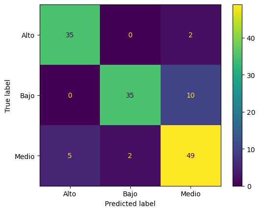

```python
%matplotlib inline
from sklearn.metrics import ConfusionMatrixDisplay
import matplotlib.pyplot as plt

ConfusionMatrixDisplay.from_estimator(best_model, X_test, y_test)
plt.show()
```

***多クラス分類モデルの評価（ターゲット変数 'Outcome'）*** OneVsRestClassifier with SVC ベース推定器を使用した多クラス分類モデルは、合計 AQ-10 スコアを基に自閉のリスクレベルを予測することに優れた性能を示しました。

**メトリクス解析:**

精度：

召回（感度または完了度）：

F1-score：

解釈：

モデルは、精度、召回、F1-score においてすべての評価メトリクスで非常に高い性能を示しています。マクロ平均および重み付き平均でも同様です。これは、モデルがすべての 3 つの自閉リスクレベルを正確に予測できることを意味します。高い精度は偽陽性率が低いことを示し、高い召回は各リスクカテゴリにおいて個人を検出する能力が良いことを示します。

ターゲット変数「austim」をマルチクラス変数として使用しました。つまり、自閉症の診断を予測変数として使用します。

```python
# Utilizamos la variable de
# diagnostico de autismo para la prediccion
import pandas as pd
from sklearn.model_selection import train_test_split
from sklearn.preprocessing import StandardScaler, OneHotEncoder
from sklearn.compose import ColumnTransformer
from sklearn.pipeline import Pipeline
from sklearn.multiclass import OneVsRestClassifier
from sklearn.svm import SVC
from sklearn.metrics import classification_report

# Re-Cargamos el DataFrame
df = pd.read_csv("autism_adult_etl.csv")

# 'austim' como variable objetivo multiclase
y = df['austim']

# Seleccionamos las características
X = df.drop(columns=['austim', 'result'])

# Dividimos en entrenamiento y prueba
X_train, X_test, y_train, y_test =\
    train_test_split(X, y, test_size=0.2, stratify=y, random_state=42)

# Preprocesado de datos (One-Hot Encoding y escalado)
numeric_features = X.select_dtypes(include=['int64', 'float64']).columns
categorical_features = X.select_dtypes(include=['object', 'category']).columns

preprocessor = ColumnTransformer(
    transformers=[
        ('num', StandardScaler(), numeric_features),
        ('cat', OneHotEncoder(), categorical_features)
    ])
# Creamos el pipeline con preprocesamiento y clasificador OneVsRest
clf = Pipeline(steps=[(
    'preprocessor', preprocessor),
                      (
                        'classifier', OneVsRestClassifier(
                            SVC(probability=True,
                                class_weight='balanced')))])

# Entrenamos el modelo en el conjunto de entrenamiento
clf.fit(X_train, y_train)

# Predecimos en el conjunto de prueba
y_pred = clf.predict(X_test)

# Evaluamos el modelo usando las etiquetas 'y_test'
print(classification_report(y_test, y_pred))
```

```
              precision    recall  f1-score   support

           0       0.91      0.77      0.83       120
           1       0.24      0.50      0.33        18

    accuracy                           0.73       138
   macro avg       0.58      0.63      0.58       138
weighted avg       0.82      0.73      0.77       138
```

***スーパーバイザーモデルの評価 - 自閉診断を予測変数とする***

自閉診断（austim）をスーパーバイザーモデルの予測変数と使用した試行は、すべてのテストされたモデルで評価メトリクスが類似しているため、評価が悪い結果を示しました。これは、自閉診断だけを考慮してモデルを構築することで、ポジティブな ASD 診断の可能性を予測する有効なモデルを構築するのに十分ではないことを示唆しています。

結論：

これらの結果に基づいて、ポジティブな自閉診断の可能性を計算する機能的なモデルを構築するには、以前の診断以外にも **AQ-10 テスト結果、その他のソシオデモグラフィックおよび行動的特徴** を考慮する必要があることがわかります。

その他の考慮事項：

- 診断の局限性：

自閉診断は複雑で健康サービスのアクセス、疾病についての知識、診断的手続きなど、様々な要因に影響を受ける場合があります。単一の予測変数として使用すると、その複雑さを取り入れることができない場合があります。

- 複数の要因の重要性：

自閉は多因子疾患であるため、個人特徴、クイズ回答、その他の関連するデータなど、複数の要因を考慮することが予測に必要であると思われます。

- その他のモデルの探索：

この作業は、このドキュメントで公開していない多数のモデルをテストした完全な探索を基にしています。そのため、複数の特徴から情報を得ることができる多様な機械学習テクニックを使用して、自閉の予測を向上させるモデルの探索を継続的に推奨します。

それでも、これらの結果は、複数の特徴を使用し、自閉の複雑さを考慮することが予測モデルを構築する際の重要性を示唆しています。 `austim` 変数または診断だけを使用すると、良好な分類性能を実現することはできないようです。

## モデル選択

### 変数選択とモデル構築の概要

探索的データ分析（EDA）とニーMLEの適用により、このデータセットで自閉の予測に最適な変数を特定することができました。

**関連変数:**

**不十分に関連する変数:**

- ジェンダー（gender）：k-means 解析とジェンダーと自閉との初期関係の検討により、関連性がわかりませんでした。したがって、最終的なモデルからこの変数は除外されました。
- 誕生時に黄疸（jundice）：サンプル内の黄疸の低い予発率と、k-means クラスターとの関連性の欠如に基づいて、この変数は自閉の予測に不十分な予測変数であると考えられ、最終的なモデル用のデータセットから削除されました。
- 居住国（res_code）：k-means 解析により、居住国はクラスターの形成に差異をもたらす因子ではないことがわかりました。したがって、この変数は最終的なモデルからも除外されました。

### 選択済みモデル：

バイナリおよび多クラス分類モデルを複数検討し、ロジスティック回帰、k-NN、ランダムフォレスト、ニューラルネットワークを含め、**多クラス分類モデル**を選択しました。 OneVsRestClassifier と SVC としてベース推定器として使用されるベースモデルに基づいています。この研究では、探索的分析で特定した関連する予測変数を使用し、カテゴリカル変数に One-Hot Encoding、数値変数にスケーリングを適用します。

## 結論

この研究は、大人の ASD リスクの検出と評価において機械学習の潜在力を示しています。データセットの局限性や問題の複雑さにもかかわらず、パフォーマンスが良好なモデルが特定されました。

探索的データ分析と特徴エンジニアリングは、最適な変数を選択するために、モデリング用のデータを準備するのに不可欠でした。 One-Hot Encoding、特徴スケーリング、SMOTE-Tomek などの再サンプリング技術の組み合わせにより、モデルのパフォーマンスが向上しました。

### 制限事項および将来の仕事：

これらの結果は特定のサンプルに基づいており、他のポップレーションに一般化できない場合があります。 さらに、モデルは、特に偽陽性を減らすことができる余地があるとも言えるほど、まだ改善の余地があります。

将来の仕事としては、より複雑なモデルを検討すること、新しい特徴を組み込むこと、より多様なポップレーションでモデルを評価することで、モデルの予測能力と一般化性を向上させることができるでしょう。

## 参考文献

- AQ-10 Adult Online Autism Test Questionnaire & PDF. (2022年, 10月 29). AutisticHub. https://www.autistichub.com/aq-10-adult-online-autism-test-questionnaire-pdf/
- Overview | Autism spectrum disorder in adults: Diagnosis and management | Guidance | NICE. (2012年, 6月 27). NICE. https://www.nice.org.uk/guidance/CG142
- Tests—Autism Research Centre. (日付なし). 読み込み 2024年9月16日, から https://www.autismresearchcentre.com/tests/
- Thabtah, F. (2017年). Autism Screening Adult [Dataset]. UCI Machine Learning Repository. https://doi.org/10.24432/C5F019
- The AQ-10 | Embrace Autism. (日付なし). 読み込み 2024年9月16日, から https://embrace-autism.com/aq-10/